# Building an Optimized Memphis Grizzlies Roster Considering the Salary Cap

**Group Members:** Jackson Burch and Joshua Burch  
**Website:** [Project Website](https://jacksonb-123.github.io/index.html)

```python
from google.colab import drive
drive.mount('/content/drive')
```

```python
!ls
```

```
drive  sample_data
```

```python
!jupyter nbconvert --to html drive/MyDrive/Project_Milestone2.ipynb
!jupyter nbconvert --to html "/content/drive/MyDrive/Project_Milestone2.ipynb"
```

```
[NbConvertApp] Converting notebook drive/MyDrive/Project_Milestone2.ipynb to html
[NbConvertApp] Writing 520752 bytes to drive/MyDrive/Project_Milestone2.html
```

```python
!ls "/content/drive/MyDrive/Colab Notebooks"
```

```
 BurchJo-Lab07.ipynb	    'BurchJoshua-Lab02 (1).ipynb'
 BurchJo-Lab08.ipynb	     BurchJoshua-Lab02.ipynb
 BurchJo-Lab09.ipynb	     BurchJoshua-Lab03.ipynb
 BurchJo-Lab10.ipynb	     BurchJoshua-Lab04.ipynb
'BurchJo-Lab11 (1).ipynb'    BurchJoshua-Lab05.ipynb
 BurchJo-Lab11.ipynb	     BurchJoshua-Lab06.ipynb
 BurchJo-Lab12.ipynb	     BurchJoshua-Lab07.ipynb
'Burch Joshua-Lab01.ipynb'  'Copy of Demo-01.ipynb'
```

```python
import pandas as pd
import numpy as np
import matplotlib.pyplot as plt
import re
import os

pd.set_option("display.max_columns", None)
pd.set_option("display.max_rows", 50)
```

## Collaboration Plan

Team members will meet at the A.B Freeman School of Business on each Thursday at 12:30pm to discuss the progress and the direction of the project. The group will discuss the work done in the Google Colab notebook reviewing code and output, analyzing before comitting changes to the git hub website. To ensure that each member understands what is being accomplished. No one team member will be tasked with a specific aspect of the plan, rather each member will help one another.

## Project Goal

The goal of this project is to investigate how the Memphis Grizzlies could hypothetically build the best roster possible while staying financially flexible. We want to combine player performance data, advanced analytics, and salary information to identify players who provide the best value relative to their contracts. We also want to explore how roster construction affects payroll and whether a team can remain under important salary thresholds such as the NBA second apron, and how reaching thresholds can limit roster flexibility.

## Main Questions

- Which NBA players provide the best value relative to their salaries?
- Which players could help improve the Memphis Grizzlies without harming long-term cap flexibility?
- How do salary structures and advanced metrics interact in roster building?

# Important facts to consider before analysis:

# Salary Rules:

There are 5 stages of salary in the NBA.

- 1. Teams under the 154.6 million dollar cap. These teams have the most flexibility and can make roster moves freely without tax penalties. As long as teams don't go below the salary floor and above the luxury tax threshold teams can make moves freely
- 2. 154.6-187.9 million dollars are teams above the cap but under the luxury tax threshold. This is where the vast majority of teams operate and there are some restrictions to being over the cap. Teams can not sign players with cap space but must use exceptions. The three exceptions used are non taxpayer midlevel exception (12-13m), bi-annual exception (4-5m)
- 3. 187.9-195.9 million dollars are teams above the tax threshold but under the first apron. Teams in this bracket are paying the luxury tax which is a progressive tax. The mid level exception can still be used in this bracket.
- 4. 195.9-207.8 million dollars are teams above the first apron but below the second apron. This bracket suffers significant roster flexibility restrictions. Teams in this bracket have lost rights to the full mid-level exception. Teams can now only use the Taxpayer midlevel exception of 5 million. Signs and trades are now unavailable. Teams are basically limited to minimum contracts.
- 5. Teams above the second apron of 207.8 million dollars suffer extreme restrictions. This bracket is almost only used by teams that are actively contending for the title. Some of the most important restrictions are teams can not use the mid level exception at all and future draft picks can be frozen or moved to the end of the round. (AthlonSports) https://athlonsports.com/nba/luxury-tax-aprons-salary-cap-how-does-it-work

## Data Sources:

1. **Historical NBA Data and Player Box Scores**
   - Source: [Kaggle — eoinamoore/historical-nba-data-and-player-box-scores](https://www.kaggle.com/datasets/eoinamoore/historical-nba-data-and-player-box-scores)
2. **NBA Player Salaries 2024–25**
   - Source: [Kaggle — ratin21/nba-player-salaries-2024-25](https://www.kaggle.com/datasets/ratin21/nba-player-salaries-2024-25)
3. **NBA Advanced Stats (Basketball Reference)**
   - Source: [Kaggle — sumitrodatta/nba-aba-baa-stats](https://www.kaggle.com/datasets/sumitrodatta/nba-aba-baa-stats)

```python
!pip install -q kagglehub
```

```python
import kagglehub
```

# Loading Data Sets:

```python
nba_path = kagglehub.dataset_download("eoinamoore/historical-nba-data-and-player-box-scores")
salary_path = kagglehub.dataset_download("ratin21/nba-player-salaries-2024-25")
#for milestone 2 we are adding advanced stats
new_path = kagglehub.dataset_download("sumitrodatta/nba-aba-baa-stats")



print("NBA dataset path:", nba_path)
print("Salary dataset path:", salary_path)
#added with milestone two
print("Advanced Stats dataset path:", new_path)

print("NBA files:", os.listdir(nba_path))
print("Salary files:", os.listdir(salary_path))
#added with mileston 2
print("Advanced Files:",os.listdir(new_path))
```

```
Downloading to /root/.cache/kagglehub/datasets/eoinamoore/historical-nba-data-and-player-box-scores/462.archive...
```

```
Extracting files...
```

```
Downloading to /root/.cache/kagglehub/datasets/ratin21/nba-player-salaries-2024-25/1.archive...
```

```
Extracting files...
```

```
Using Colab cache for faster access to the 'nba-aba-baa-stats' dataset.
NBA dataset path: /root/.cache/kagglehub/datasets/eoinamoore/historical-nba-data-and-player-box-scores/versions/462
Salary dataset path: /root/.cache/kagglehub/datasets/ratin21/nba-player-salaries-2024-25/versions/1
Advanced Stats dataset path: /kaggle/input/nba-aba-baa-stats
NBA files: ['LeagueSchedule24_25.csv', 'PlayByPlay.parquet', 'LeagueSchedule25_26.csv', 'Games.csv', 'PlayerStatistics.csv', 'TeamStatistics.csv', 'TeamHistories.csv', 'PlayerStatisticsExtended.csv', 'TeamStatisticsExtended.csv', 'Players.csv']
Salary files: ['NBA Player Salaries_2024-25_1.csv']
Advanced Files: ['Advanced.csv', 'Player Season Info.csv', 'Player Career Info.csv', 'Player Shooting.csv', 'Opponent Stats Per Game.csv', 'Draft Pick History.csv', 'Player Totals.csv', 'Opponent Stats Per 100 Poss.csv', 'Per 100 Poss.csv', 'Team Summaries.csv', 'Player Per Game.csv', 'All-Star Sele…
```

```python
print("Advanced Files:", os.listdir(new_path))
```

```
Advanced Files: ['Advanced.csv', 'Player Season Info.csv', 'Player Career Info.csv', 'Player Shooting.csv', 'Opponent Stats Per Game.csv', 'Draft Pick History.csv', 'Player Totals.csv', 'Opponent Stats Per 100 Poss.csv', 'Per 100 Poss.csv', 'Team Summaries.csv', 'Player Per Game.csv', 'All-Star Sele…
```

```python
players = pd.read_csv(os.path.join(nba_path, "Players.csv"))
player_stats = pd.read_csv(os.path.join(nba_path, "PlayerStatistics.csv"))
salaries = pd.read_csv(os.path.join(salary_path, "NBA Player Salaries_2024-25_1.csv"))
advanced = pd.read_csv(os.path.join(new_path, "Advanced.csv"))

print("Players columns:")
print(list(players.columns))
display(players.head())

print("\nPlayer stats columns:")
print(player_stats.columns.tolist())
display(player_stats.head())

print("\nSalary columns:")
print(salaries.columns.tolist())
display(salaries.head())

print("\nAdvanced stats coloumns:")
print(advanced.columns.tolist())
display(advanced.head())
```

```
Players columns:
['personId', 'firstName', 'lastName', 'birthDate', 'school', 'country', 'heightInches', 'bodyWeightLbs', 'jersey', 'guard', 'forward', 'center', 'dleagueFlag', 'nbaFlag', 'gamesPlayedFlag', 'draftYear', 'draftRound', 'draftNumber', 'fromYear', 'toYear']
```

|  | personId | firstName | lastName | birthDate | school | country | heightInches | bodyWeightLbs | jersey | guard | forward | center | dleagueFlag | nbaFlag | gamesPlayedFlag | draftYear | draftRound | draftNumber | fromYear | toYear |
| --- | --- | --- | --- | --- | --- | --- | --- | --- | --- | --- | --- | --- | --- | --- | --- | --- | --- | --- | --- | --- |
| 0 | 196294534 | Alberto | Abalde | NaN | NaN | NaN | NaN | NaN | NaN | 0 | 0 | 0 | NaN | NaN | NaN | NaN | NaN | NaN | NaN | NaN |
| 1 | 76001 | Alaa | Abdelnaby | 1968-06-24 | Duke | USA | 82.0 | 240.0 | 30 | 0 | 1 | 0 | 0.0 | 1.0 | 1.0 | 1990.0 | 1.0 | 25.0 | 1990.0 | 1994.0 |
| 2 | 76002 | Zaid | Abdul-Aziz | 1946-04-07 | Iowa State | USA | 81.0 | 235.0 | 54 | 0 | 0 | 1 | 0.0 | 1.0 | 1.0 | 1968.0 | 1.0 | 5.0 | 1968.0 | 1977.0 |
| 3 | 76003 | Kareem | Abdul-Jabbar | 1947-04-16 | UCLA | USA | 86.0 | 225.0 | 33 | 0 | 0 | 1 | 0.0 | 1.0 | 1.0 | 1969.0 | 1.0 | 1.0 | 1969.0 | 1988.0 |
| 4 | 51 | Mahmoud | Abdul-Rauf | 1969-03-09 | Louisiana State | USA | 73.0 | 162.0 | 1 | 1 | 0 | 0 | 0.0 | 1.0 | 1.0 | 1990.0 | 1.0 | 3.0 | 1990.0 | 2000.0 |

```
Player stats columns:
['firstName', 'lastName', 'personId', 'gameId', 'gameDateTimeEst', 'playerteamCity', 'playerteamName', 'opponentteamCity', 'opponentteamName', 'gameType', 'gameLabel', 'gameSubLabel', 'seriesGameNumber', 'win', 'home', 'numMinutes', 'points', 'assists', 'blocks', 'steals', 'fieldGoalsAttempted', 'fi…
```

|  | firstName | lastName | personId | gameId | gameDateTimeEst | playerteamCity | playerteamName | opponentteamCity | opponentteamName | gameType | gameLabel | gameSubLabel | seriesGameNumber | win | home | numMinutes | points | assists | blocks | steals | fieldGoalsAttempted | fieldGoalsMade | fieldGoalsPercentage | threePointersAttempted | threePointersMade | threePointersPercentage | freeThrowsAttempted | freeThrowsMade | freeThrowsPercentage | … |
| --- | --- | --- | --- | --- | --- | --- | --- | --- | --- | --- | --- | --- | --- | --- | --- | --- | --- | --- | --- | --- | --- | --- | --- | --- | --- | --- | --- | --- | --- | --- |
| 0 | Tim | Hardaway Jr. | 203501.0 | 42500163 | 2026-04-23 21:30:00 | Denver | Nuggets | Minnesota | Timberwolves | Playoffs | West First Round | Game 3 | 3 | 0.0 | 0.0 | 27.983333 | 11.0 | 0.0 | 0.0 | 0.0 | 8.0 | 3.0 | 0.375 | 6.0 | 2.0 | 0.333 | 4.0 | 3.0 | 0.75 | … |
| 1 | Kyle | Anderson | 203937.0 | 42500163 | 2026-04-23 21:30:00 | Minnesota | Timberwolves | Denver | Nuggets | Playoffs | West First Round | Game 3 | 3 | 1.0 | 1.0 | 5.266667 | 0.0 | 0.0 | 0.0 | 0.0 | 1.0 | 0.0 | 0.000 | 0.0 | 0.0 | 0.000 | 0.0 | 0.0 | 0.00 | … |
| 2 | Cameron | Johnson | 1629661.0 | 42500163 | 2026-04-23 21:30:00 | Denver | Nuggets | Minnesota | Timberwolves | Playoffs | West First Round | Game 3 | 3 | 0.0 | 0.0 | 23.616667 | 6.0 | 1.0 | 0.0 | 1.0 | 6.0 | 2.0 | 0.333 | 3.0 | 0.0 | 0.000 | 2.0 | 2.0 | 1.00 | … |
| 3 | Jonas | Valanciunas | 202685.0 | 42500163 | 2026-04-23 21:30:00 | Denver | Nuggets | Minnesota | Timberwolves | Playoffs | West First Round | Game 3 | 3 | 0.0 | 0.0 | NaN | 0.0 | 0.0 | 0.0 | 0.0 | 0.0 | 0.0 | 0.000 | 0.0 | 0.0 | 0.000 | 0.0 | 0.0 | 0.00 | … |
| 4 | Joe | Ingles | 204060.0 | 42500163 | 2026-04-23 21:30:00 | Minnesota | Timberwolves | Denver | Nuggets | Playoffs | West First Round | Game 3 | 3 | 1.0 | 1.0 | 0.7 | 0.0 | 0.0 | 0.0 | 0.0 | 0.0 | 0.0 | 0.000 | 0.0 | 0.0 | 0.000 | 0.0 | 0.0 | 0.00 | … |

```
Salary columns:
['Player', 'Team', 'Salary']
```

|  | Player | Team | Salary |
| --- | --- | --- | --- |
| 0 | Stephen Curry | GSW | $55,761,216 |
| 1 | Joel Embiid | PHI | $51,415,938 |
| 2 | Nikola Jokic | DEN | $51,415,938 |
| 3 | Kevin Durant | PHO | $51,179,021 |
| 4 | Bradley Beal | PHO | $50,203,930 |

```
Advanced stats coloumns:
['season', 'lg', 'player', 'player_id', 'age', 'team', 'pos', 'g', 'gs', 'mp', 'per', 'ts_percent', 'x3p_ar', 'f_tr', 'orb_percent', 'drb_percent', 'trb_percent', 'ast_percent', 'stl_percent', 'blk_percent', 'tov_percent', 'usg_percent', 'ows', 'dws', 'ws', 'ws_48', 'obpm', 'dbpm', 'bpm', 'vorp']
```

|  | season | lg | player | player_id | age | team | pos | g | gs | mp | per | ts_percent | x3p_ar | f_tr | orb_percent | drb_percent | trb_percent | ast_percent | stl_percent | blk_percent | tov_percent | usg_percent | ows | dws | ws | ws_48 | obpm | dbpm | bpm | … |
| --- | --- | --- | --- | --- | --- | --- | --- | --- | --- | --- | --- | --- | --- | --- | --- | --- | --- | --- | --- | --- | --- | --- | --- | --- | --- | --- | --- | --- | --- | --- |
| 0 | 2026 | NBA | Precious Achiuwa | achiupr01 | 26.0 | SAC | C | 73 | 57.0 | 1745.0 | 16.2 | 0.558 | 0.162 | 0.232 | 11.0 | 20.8 | 15.8 | 8.5 | 1.8 | 2.6 | 9.0 | 17.6 | 1.8 | 1.2 | 2.9 | 0.081 | -0.5 | -1.1 | -1.6 | … |
| 1 | 2026 | NBA | Steven Adams | adamsst01 | 32.0 | HOU | C | 32 | 11.0 | 730.0 | 15.8 | 0.535 | 0.000 | 0.583 | 22.3 | 19.6 | 21.0 | 8.3 | 1.5 | 2.5 | 16.7 | 12.1 | 1.1 | 1.0 | 2.1 | 0.141 | -0.1 | -0.3 | -0.5 | … |
| 2 | 2026 | NBA | Bam Adebayo | adebaba01 | 28.0 | MIA | C | 73 | 73.0 | 2365.0 | 18.7 | 0.551 | 0.349 | 0.369 | 6.5 | 25.7 | 16.1 | 14.1 | 1.7 | 1.8 | 8.3 | 25.0 | 2.8 | 3.6 | 6.4 | 0.129 | 1.5 | 0.4 | 2.0 | … |
| 3 | 2026 | NBA | Ochai Agbaji | agbajoc01 | 25.0 | 2TM | SG | 62 | 13.0 | 973.0 | 8.9 | 0.525 | 0.457 | 0.154 | 5.3 | 11.5 | 8.3 | 6.8 | 1.2 | 1.7 | 9.4 | 14.6 | 0.1 | 0.8 | 0.9 | 0.046 | -3.5 | -0.5 | -4.0 | … |
| 4 | 2026 | NBA | Ochai Agbaji | agbajoc01 | 25.0 | TOR | SG | 42 | 13.0 | 650.0 | 7.5 | 0.495 | 0.382 | 0.171 | 5.7 | 10.9 | 8.3 | 6.0 | 1.3 | 1.6 | 9.4 | 13.3 | 0.0 | 0.7 | 0.6 | 0.048 | -4.8 | 0.1 | -4.7 | … |

By combining player stats with salary data, we can calculate metrics like points per million dollars. This helps measure how much production a team is getting for what they pay. We also use salary totals to classify each team by their NBA salary cap tier, which determines what roster moves they are allowed to make.

# Standardizing Player Names

- Across data sets, the names are input differently
- Need to standarized names to properly merge data sets

```python
def clean_name(name):
    if pd.isna(name):
        return np.nan
    name = str(name).strip().lower()
    name = re.sub(r"\b(jr|sr|ii|iii|iv)\b\.?", "", name)
    name = re.sub(r"[^\w\s-]", "", name)
    name = re.sub(r"\s+", " ", name).strip()
    return name
```

```python
print(salaries.columns)
```

```
Index(['Player', 'Team', 'Salary'], dtype='object')
```

```python
players["full_name"] = (
    players["firstName"].fillna("").astype(str).str.strip() + " " +
    players["lastName"].fillna("").astype(str).str.strip()
).str.strip()

players["player_name_clean"] = players["full_name"].apply(clean_name)
salaries["player_name_clean"] = salaries["Player"].apply(clean_name)
```

# Cleaning The Advanced Stats Data Set:

- Filter out other basketball leagues such as the G league
- Avoid duplicate players that played for multiple teams across the 2024-2025 NBA Season

```python
advanced["player_name_clean"] = advanced["player"].apply(clean_name)

# Keep only NBA
advanced = advanced[advanced["lg"] == "NBA"].copy()

# Prioritize combined rows if they exist
advanced["team_priority"] = (advanced["team"] != "2TM").astype(int)

advanced = advanced.sort_values(
    by=["player_name_clean", "team_priority"]
)

# Keep one row per player
advanced = advanced.drop_duplicates(
    subset=["player_name_clean"],
    keep="first"
)
```

# Tidying Each Data Set

- We select only the columns we actually need across the 3 data sets
- This helps the table look cleaner for when we merge

```python
players_tidy = players[[
    "personId", "full_name", "player_name_clean",
    "heightInches", "bodyWeightLbs", "draftYear",
    "guard", "forward", "center"
]].copy()
```

```python
#clean stats
player_stats["numMinutes"] = pd.to_numeric(player_stats["numMinutes"], errors="coerce")
player_stats["points"] = pd.to_numeric(player_stats["points"], errors="coerce")
player_stats["reboundsTotal"] = pd.to_numeric(player_stats["reboundsTotal"], errors="coerce")
player_stats["assists"] = pd.to_numeric(player_stats["assists"], errors="coerce")
player_stats["gameId"] = pd.to_numeric(player_stats["gameId"], errors="coerce")
#tidy the clean stats
stats_tidy = player_stats.groupby("personId", as_index=False).agg(
    gamesPlayed=("gameId", "count"),
    minutes=("numMinutes", "sum"),
    points=("points", "sum"),
    reboundsTotal=("reboundsTotal", "sum"),
    assists=("assists", "sum")
)

stats_tidy["points_per_game"] = stats_tidy["points"] / stats_tidy["gamesPlayed"]
stats_tidy["rebounds_per_game"] = stats_tidy["reboundsTotal"] / stats_tidy["gamesPlayed"]
stats_tidy["assists_per_game"] = stats_tidy["assists"] / stats_tidy["gamesPlayed"]

display(stats_tidy.head())
print(stats_tidy.dtypes)
```

|  | personId | gamesPlayed | minutes | points | reboundsTotal | assists | points_per_game | rebounds_per_game | assists_per_game |
| --- | --- | --- | --- | --- | --- | --- | --- | --- | --- |
| 0 | 2.0 | 1260 | 35467.0 | 17548.0 | 3523.0 | 3119.0 | 13.926984 | 2.796032 | 2.475397 |
| 1 | 3.0 | 1090 | 29521.0 | 9891.0 | 6397.0 | 1775.0 | 9.074312 | 5.868807 | 1.628440 |
| 2 | 7.0 | 1275 | 23224.0 | 9321.0 | 5985.0 | 1372.0 | 7.310588 | 4.694118 | 1.076078 |
| 3 | 9.0 | 1027 | 23935.0 | 9935.0 | 1819.0 | 3864.0 | 9.673807 | 1.771178 | 3.762415 |
| 4 | 12.0 | 112 | 2064.0 | 693.0 | 311.0 | 116.0 | 6.187500 | 2.776786 | 1.035714 |

```
personId             float64
gamesPlayed            int64
minutes              float64
points               float64
reboundsTotal        float64
assists              float64
points_per_game      float64
rebounds_per_game    float64
assists_per_game     float64
dtype: object
```

```python
salaries_tidy = salaries[[
    "Player", "Team", "Salary", "player_name_clean"
]].copy()

salaries_tidy["Salary"] = (
    salaries_tidy["Salary"]
    .astype(str)
    .str.replace("$", "", regex=False)
    .str.replace(",", "", regex=False)
)

salaries_tidy["Salary"] = pd.to_numeric(salaries_tidy["Salary"], errors="coerce")

display(salaries_tidy.head())
print(salaries_tidy.dtypes)
```

|  | Player | Team | Salary | player_name_clean |
| --- | --- | --- | --- | --- |
| 0 | Stephen Curry | GSW | 55761216 | stephen curry |
| 1 | Joel Embiid | PHI | 51415938 | joel embiid |
| 2 | Nikola Jokic | DEN | 51415938 | nikola jokic |
| 3 | Kevin Durant | PHO | 51179021 | kevin durant |
| 4 | Bradley Beal | PHO | 50203930 | bradley beal |

```
Player               object
Team                 object
Salary                int64
player_name_clean    object
dtype: object
```

The salaries were formatted as strings. We changed the salary format to numeric.

# Selecting the Advanced Stats Coloums

- keep only the relevant advanced stats:
  - age
  - PER
  - True Shooting %
  - Usage Rate
  - WS/48
  - BPM
  - VORP

```python
advanced_tidy = advanced[[
    "player_name_clean",
    "age",
    "per",
    "ts_percent",
    "usg_percent",
    "ws_48",
    "bpm",
    "vorp"
]].copy()

advanced_tidy = advanced_tidy.drop_duplicates(
    subset=["player_name_clean"],
    keep="first"
).copy()
```

# Team Payroll Totals

- Sum each indivdual teams players salary to calculate payroll
- Will help us classify which salary cap tier each team falls into
  - Leads to insight on each team's roster flexibility

```python
team_payroll = (
    salaries_tidy.groupby("Team", as_index=False)["Salary"]
    .sum()
    .rename(columns={"Salary": "team_payroll"})
    .sort_values("team_payroll", ascending=False)
)

team_payroll["team_payroll_millions"] = team_payroll["team_payroll"] / 1_000_000

display(team_payroll)
```

|  | Team | team_payroll | team_payroll_millions |
| --- | --- | --- | --- |
| 19 | NYK | 224453205 | 224.453205 |
| 23 | PHO | 214371340 | 214.371340 |
| 12 | LAC | 209976537 | 209.976537 |
| 17 | MIN | 202984505 | 202.984505 |
| 1 | BOS | 196193787 | 196.193787 |
| 13 | LAL | 190333390 | 190.333390 |
| 7 | DEN | 184901840 | 184.901840 |
| 16 | MIL | 184821334 | 184.821334 |
| 29 | WAS | 177805812 | 177.805812 |
| 9 | GSW | 177788653 | 177.788653 |
| 18 | NOP | 176867649 | 176.867649 |
| 27 | TOR | 176715419 | 176.715419 |
| 6 | DAL | 175713151 | 175.713151 |
| 22 | PHI | 174099727 | 174.099727 |
| 15 | MIA | 173088172 | 173.088172 |
| 5 | CLE | 171830703 | 171.830703 |
| 2 | BRK | 170679382 | 170.679382 |
| 11 | IND | 170491374 | 170.491374 |
| 25 | SAC | 169452829 | 169.452829 |
| 10 | HOU | 169075720 | 169.075720 |
| 0 | ATL | 168501372 | 168.501372 |
| 20 | OKC | 168312325 | 168.312325 |
| 4 | CHO | 168072310 | 168.072310 |
| 24 | POR | 167086613 | 167.086613 |
| 3 | CHI | 166699174 | 166.699174 |
| 28 | UTA | 166528900 | 166.528900 |
| 14 | MEM | 165112861 | 165.112861 |
| 26 | SAS | 163459208 | 163.459208 |
| 21 | ORL | 150359238 | 150.359238 |
| 8 | DET | 145721454 | 145.721454 |

# Memphis Grizzlies Salary Totals

- Tells us who plays for the Grizzlies and what they are paid

```python
grizzlies_players = (
    salaries_tidy[salaries_tidy["Team"] == "MEM"]
    .drop_duplicates(subset=["Player", "Team", "Salary"])
    .sort_values("Salary", ascending=False)
    .copy()
)

grizzlies_players["Salary_millions"] = grizzlies_players["Salary"] / 1_000_000

display(grizzlies_players)
```

|  | Player | Team | Salary | player_name_clean | Salary_millions |
| --- | --- | --- | --- | --- | --- |
| 28 | Ja Morant | MEM | 36725670 | ja morant | 36.725670 |
| 41 | Desmond Bane | MEM | 34005250 | desmond bane | 34.005250 |
| 63 | Jaren Jackson Jr. | MEM | 25257798 | jaren jackson | 25.257798 |
| 134 | Brandon Clarke | MEM | 12500000 | brandon clarke | 12.500000 |
| 135 | Marvin Bagley III | MEM | 12500000 | marvin bagley | 12.500000 |
| 172 | Luke Kennard | MEM | 9250000 | luke kennard | 9.250000 |
| 221 | John Konchar | MEM | 6165000 | john konchar | 6.165000 |
| 229 | Zach Edey | MEM | 5756880 | zach edey | 5.756880 |
| 235 | Johnny Davis | MEM | 5291160 | johnny davis | 5.291160 |
| 275 | Santi Aldama | MEM | 3960531 | santi aldama | 3.960531 |
| 358 | Vince Williams Jr. | MEM | 2120693 | vince williams | 2.120693 |
| 364 | Jay Huff | MEM | 2088033 | jay huff | 2.088033 |
| 366 | Scotty Pippen Jr. | MEM | 2087519 | scotty pippen | 2.087519 |
| 408 | Kennedy Chandler | MEM | 2019699 | kennedy chandler | 2.019699 |
| 412 | GG Jackson II | MEM | 1891857 | gg jackson | 1.891857 |
| 443 | Jaylen Wells | MEM | 1157153 | jaylen wells | 1.157153 |
| 486 | Lamar Stevens | MEM | 623856 | lamar stevens | 0.623856 |
| 481 | Mamadi Diakite | MEM | 464050 | mamadi diakite | 0.464050 |

```python
memphis_payroll = grizzlies_players["Salary"].sum()

print("Memphis total payroll:", memphis_payroll)
print("Memphis payroll (millions):", memphis_payroll / 1_000_000)
```

```
Memphis total payroll: 163865149
Memphis payroll (millions): 163.865149
```

The Grizzlies total salary is $163,865,149 dollars

# Merging the Data Sets

Merging the data sets is important because you can compare players production with their salries. This allows insignts into whether players are overpaid, underpaid, or at fair value. Information on player value is critical when creating potential trades.

```python
player_info = players_tidy.merge(stats_tidy, on="personId", how="inner")

full_data = player_info.merge(
    salaries_tidy,
    on="player_name_clean",
    how="inner"
)

print("Merged shape:", full_data.shape)
display(full_data.head())
```

```
Merged shape: (583, 20)
```

|  | personId | full_name | player_name_clean | heightInches | bodyWeightLbs | draftYear | guard | forward | center | gamesPlayed | minutes | points | reboundsTotal | assists | points_per_game | rebounds_per_game | assists_per_game | Player | Team | Salary |
| --- | --- | --- | --- | --- | --- | --- | --- | --- | --- | --- | --- | --- | --- | --- | --- | --- | --- | --- | --- | --- |
| 0 | 1630173 | Precious Achiuwa | precious achiuwa | 80.0 | 243.0 | 2020.0 | 0 | 1 | 0 | 488 | 8826.050000 | 3506.0 | 2546.0 | 448.0 | 7.184426 | 5.217213 | 0.918033 | Precious Achiuwa | NYK | 6000000 |
| 1 | 203500 | Steven Adams | steven adams | 83.0 | 265.0 | 2013.0 | 0 | 0 | 1 | 968 | 22923.930000 | 7948.0 | 7298.0 | 1324.0 | 8.210744 | 7.539256 | 1.367769 | Steven Adams | HOU | 12600000 |
| 2 | 1628389 | Bam Adebayo | bam adebayo | 81.0 | 255.0 | 2017.0 | 0 | 1 | 1 | 811 | 23123.090000 | 12231.0 | 6759.0 | 2646.0 | 15.081381 | 8.334155 | 3.262639 | Bam Adebayo | MIA | 34848340 |
| 3 | 1630534 | Ochai Agbaji | ochai agbaji | 77.0 | 215.0 | 2022.0 | 1 | 0 | 0 | 320 | 5805.840000 | 2047.0 | 782.0 | 316.0 | 6.396875 | 2.443750 | 0.987500 | Ochai Agbaji | TOR | 4310280 |
| 4 | 1630583 | Santi Aldama | santi aldama | 84.0 | 215.0 | 2021.0 | 0 | 1 | 1 | 364 | 7162.956667 | 3259.0 | 1721.0 | 631.0 | 8.953297 | 4.728022 | 1.733516 | Santi Aldama | MEM | 3960531 |

Merge the advanced stats:

```python
print("Before merge:", full_data.shape)
full_data = full_data.merge(
    advanced_tidy,
    on="player_name_clean",
    how="left"
)
print("After merge:", full_data.shape)
```

```
Before merge: (583, 20)
After merge: (583, 27)
```

confirm that the row total are equal and no players are dropped

```python
print("Rows before cleaning:", len(full_data))
print("Unique players before cleaning:", full_data["player_name_clean"].nunique())

full_data = full_data.drop_duplicates(subset=["player_name_clean"], keep="first").copy()

print("Rows after cleaning:", len(full_data))
print("Unique players after cleaning:", full_data["player_name_clean"].nunique())

print("Cleaned Memphis players:")
display(
    full_data[full_data["Team"] == "MEM"][["full_name", "Salary"]]
    .sort_values("Salary", ascending=False)
)
```

```
Rows before cleaning: 583
Unique players before cleaning: 513
Rows after cleaning: 513
Unique players after cleaning: 513
Cleaned Memphis players:
```

|  | full_name | Salary |
| --- | --- | --- |
| 354 | Ja Morant | 36725670 |
| 24 | Desmond Bane | 34005250 |
| 236 | Jaren Jackson | 25257798 |
| 17 | Marvin Bagley III | 12500000 |
| 100 | Brandon Clarke | 12500000 |
| 269 | Luke Kennard | 9250000 |
| 281 | John Konchar | 6165000 |
| 150 | Zach Edey | 5756880 |
| 123 | Johnny Davis | 5291160 |
| 4 | Santi Aldama | 3960531 |
| 571 | Vince Williams Jr. | 2120693 |
| 224 | Jay Huff | 2088033 |
| 398 | Scotty Pippen Jr. | 2087519 |
| 95 | Kennedy Chandler | 2019699 |
| 234 | GG Jackson | 1891857 |
| 547 | Jaylen Wells | 1157153 |
| 486 | Lamar Stevens | 623856 |
| 131 | Mamadi Diakite | 464050 |

```python
# Manually name matches
print("Jackson names in full_data:")
print(full_data[full_data["full_name"].str.contains("Jackson", case=False)]["full_name"].tolist())

print("\nJackson names in salaries_tidy:")
print(salaries_tidy[salaries_tidy["Player"].str.contains("Jackson", case=False)]["Player"].tolist())
```

```
Jackson names in full_data:
['GG Jackson', 'Isaiah Jackson', 'Jaren Jackson', 'Reggie Jackson', 'Andre Jackson Jr.', 'Trayce Jackson-Davis']

Jackson names in salaries_tidy:
['Jaren Jackson Jr.', 'Isaiah Jackson', 'Reggie Jackson', 'Reggie Jackson', 'GG Jackson II', 'Andre Jackson Jr.', 'Trayce Jackson-Davis']
```

```python
# force the salary names to match what's in full_data
name_fix_map = {
    "jaren jackson"   : "jaren jackson",   # both sides strip Jr. — should match
    "gg jackson"      : "gg jackson",      # both sides strip II — should match
}

print("Jaren Jackson in Players.csv:")
print(players[players["lastName"].str.contains("Jackson", case=False, na=False)][
    ["firstName","lastName","full_name","player_name_clean"]
])

print("\nGG Jackson in Players.csv:")
print(players[players["firstName"].str.contains("GG|G.G", case=False, na=False, regex=True)][
    ["firstName","lastName","full_name","player_name_clean"]
])
```

```
Jaren Jackson in Players.csv:
      firstName            lastName                  full_name  \
2780      Aaron             Jackson              Aaron Jackson
2781      Aaron             Jackson              Aaron Jackson
2782  Aaron Lee             Jackson          Aaron Lee Jackson
2783         Al             Jackson                 Al Jackson
2784      Bobby             Jackson              Bobby Jackson
2785     Cedric             Jackson             Cedric Jackson
2786    Darnell             Jackson            Darnell Jackson
2787      David             Jackson              David Jackson
2788      David             Jackson              David Jackson
2789  Demetrius             Jackson          Demetrius Jackson
2790      Frank             Jackson              Frank Jackson
2791         GG             Jackson                 GG Jackson
2792       Greg             Jackson               Greg Jackson
```

[output cut: 101 more lines]

ensure that salary names match to the full data. Cases such Jr. and suffixes cause errors

```python
print(full_data.columns.tolist())
```

```
['personId', 'full_name', 'player_name_clean', 'heightInches', 'bodyWeightLbs', 'draftYear', 'guard', 'forward', 'center', 'gamesPlayed', 'minutes', 'points', 'reboundsTotal', 'assists', 'points_per_game', 'rebounds_per_game', 'assists_per_game', 'Player', 'Team', 'Salary', 'age', 'per', 'ts_percent…
```

```python
print("Merged shape:", full_data.shape)
print("Number of players:", full_data["full_name"].nunique())

display(full_data.head())

print("\nData types:")
print(full_data.dtypes)

print("\nMissing values:")
print(full_data.isna().sum())
```

```
Merged shape: (513, 27)
Number of players: 513
```

|  | personId | full_name | player_name_clean | heightInches | bodyWeightLbs | draftYear | guard | forward | center | gamesPlayed | minutes | points | reboundsTotal | assists | points_per_game | rebounds_per_game | assists_per_game | Player | Team | Salary | age | per | ts_percent | usg_percent | ws_48 | bpm | vorp |
| --- | --- | --- | --- | --- | --- | --- | --- | --- | --- | --- | --- | --- | --- | --- | --- | --- | --- | --- | --- | --- | --- | --- | --- | --- | --- | --- | --- |
| 0 | 1630173 | Precious Achiuwa | precious achiuwa | 80.0 | 243.0 | 2020.0 | 0 | 1 | 0 | 488 | 8826.050000 | 3506.0 | 2546.0 | 448.0 | 7.184426 | 5.217213 | 0.918033 | Precious Achiuwa | NYK | 6000000 | 24.0 | 14.6 | 0.545 | 15.9 | 0.102 | -1.4 | 0.2 |
| 1 | 203500 | Steven Adams | steven adams | 83.0 | 265.0 | 2013.0 | 0 | 0 | 1 | 968 | 22923.930000 | 7948.0 | 7298.0 | 1324.0 | 8.210744 | 7.539256 | 1.367769 | Steven Adams | HOU | 12600000 | 32.0 | 15.8 | 0.535 | 12.1 | 0.141 | -0.5 | 0.3 |
| 2 | 1628389 | Bam Adebayo | bam adebayo | 81.0 | 255.0 | 2017.0 | 0 | 1 | 1 | 811 | 23123.090000 | 12231.0 | 6759.0 | 2646.0 | 15.081381 | 8.334155 | 3.262639 | Bam Adebayo | MIA | 34848340 | 28.0 | 18.7 | 0.551 | 25.0 | 0.129 | 2.0 | 2.4 |
| 3 | 1630534 | Ochai Agbaji | ochai agbaji | 77.0 | 215.0 | 2022.0 | 1 | 0 | 0 | 320 | 5805.840000 | 2047.0 | 782.0 | 316.0 | 6.396875 | 2.443750 | 0.987500 | Ochai Agbaji | TOR | 4310280 | 25.0 | 8.9 | 0.525 | 14.6 | 0.046 | -4.0 | -0.5 |
| 4 | 1630583 | Santi Aldama | santi aldama | 84.0 | 215.0 | 2021.0 | 0 | 1 | 1 | 364 | 7162.956667 | 3259.0 | 1721.0 | 631.0 | 8.953297 | 4.728022 | 1.733516 | Santi Aldama | MEM | 3960531 | 25.0 | 16.3 | 0.572 | 20.2 | 0.092 | 1.7 | 1.1 |

```
Data types:
personId               int64
full_name             object
player_name_clean     object
heightInches         float64
bodyWeightLbs        float64
draftYear            float64
guard                  int64
forward                int64
center                 int64
gamesPlayed            int64
minutes              float64
points               float64
reboundsTotal        float64
assists              float64
points_per_game      float64
rebounds_per_game    float64
assists_per_game     float64
Player                object
Team                  object
Salary                 int64
age                  float64
per                  float64
ts_percent           float64
usg_percent          float64
ws_48                float64
bpm                  float64
vorp                 float64
dtype: object

Missing values:
personId              0
full_name             0
player_name_clean     0
heightInches          4
bodyWeightLbs         5
draftYear             1
guard                 0
forward               0
center                0
gamesPlayed           0
minutes               0
points                0
reboundsTotal         0
assists               0
points_per_game       0
rebounds_per_game     0
assists_per_game      0
Player                0
Team                  0
Salary                0
age                  21
per                  21
ts_percent           21
usg_percent          21
ws_48                21
bpm                  21
vorp                 21
dtype: int64
```

Merging player info, production, and salary datainto a single player level data set. We now have a data table where a row is an individual player and the coloums are specific infromation about the player

## Positions

- the data sets store the positions as binary
- convert the binary labels to readable position strings

```python
def get_position(row):
    guard = str(row["guard"]).strip()
    forward = str(row["forward"]).strip()
    center = str(row["center"]).strip()

    if guard == "1" and forward == "1":
        return "Guard-Forward"
    elif forward == "1" and center == "1":
        return "Forward-Center"
    elif guard == "1":
        return "Guard"
    elif forward == "1":
        return "Forward"
    elif center == "1":
        return "Center"
    else:
        return "Unknown"

full_data["Position"] = full_data.apply(get_position, axis=1)

display(full_data[["full_name", "guard", "forward", "center", "Position"]].head())
```

|  | full_name | guard | forward | center | Position |
| --- | --- | --- | --- | --- | --- |
| 0 | Precious Achiuwa | 0 | 1 | 0 | Forward |
| 1 | Steven Adams | 0 | 0 | 1 | Center |
| 2 | Bam Adebayo | 0 | 1 | 1 | Forward-Center |
| 3 | Ochai Agbaji | 1 | 0 | 0 | Guard |
| 4 | Santi Aldama | 0 | 1 | 1 | Forward-Center |

Analysis based on positional needs can now be accomplished since players now have a singular positional label

# Basic Value Metrics:

- Value statistics per 1 million dollars

```python
full_data["salary_millions"] = full_data["Salary"] / 1_000_000

# Basic production per million dollars
full_data["points_per_million"] = full_data["points"] / full_data["salary_millions"]
full_data["rebounds_per_million"] = full_data["reboundsTotal"] / full_data["salary_millions"]
full_data["assists_per_million"] = full_data["assists"] / full_data["salary_millions"]

# Combined simple value score
full_data["basic_value_score"] = (
    full_data["points"] + full_data["reboundsTotal"] + full_data["assists"]
) / full_data["salary_millions"]

display(full_data[[
    "full_name", "Team", "Salary", "points", "reboundsTotal", "assists",
    "points_per_million", "rebounds_per_million", "assists_per_million", "basic_value_score"
]].head())
```

|  | full_name | Team | Salary | points | reboundsTotal | assists | points_per_million | rebounds_per_million | assists_per_million | basic_value_score |
| --- | --- | --- | --- | --- | --- | --- | --- | --- | --- | --- |
| 0 | Precious Achiuwa | NYK | 6000000 | 3506.0 | 2546.0 | 448.0 | 584.333333 | 424.333333 | 74.666667 | 1083.333333 |
| 1 | Steven Adams | HOU | 12600000 | 7948.0 | 7298.0 | 1324.0 | 630.793651 | 579.206349 | 105.079365 | 1315.079365 |
| 2 | Bam Adebayo | MIA | 34848340 | 12231.0 | 6759.0 | 2646.0 | 350.977981 | 193.954719 | 75.929011 | 620.861711 |
| 3 | Ochai Agbaji | TOR | 4310280 | 2047.0 | 782.0 | 316.0 | 474.911143 | 181.426729 | 73.313103 | 729.650974 |
| 4 | Santi Aldama | MEM | 3960531 | 3259.0 | 1721.0 | 631.0 | 822.869459 | 434.537692 | 159.322071 | 1416.729221 |

```python
top_value_players = (
    full_data[[
        "full_name", "Team", "Salary", "points", "reboundsTotal", "assists", "basic_value_score"
    ]]
    .sort_values("basic_value_score", ascending=False)
    .head(15)
)

display(top_value_players)
```

|  | full_name | Team | Salary | points | reboundsTotal | assists | basic_value_score |
| --- | --- | --- | --- | --- | --- | --- | --- |
| 125 | Terence Davis | SAC | 64301 | 2086.0 | 709.0 | 354.0 | 48972.799801 |
| 444 | Ricky Rubio | CLE | 424672 | 8117.0 | 3013.0 | 5464.0 | 39074.862482 |
| 126 | JD Davison | BOS | 11997 | 231.0 | 91.0 | 113.0 | 36259.064766 |
| 376 | Jahlil Okafor | IND | 119972 | 2753.0 | 1264.0 | 250.0 | 35566.632214 |
| 207 | Killian Hayes | BRK | 119972 | 2007.0 | 718.0 | 1248.0 | 33116.060414 |
| 271 | Braxton Key | GSW | 11997 | 182.0 | 123.0 | 34.0 | 28257.064266 |
| 60 | Oshae Brissett | PHI | 119972 | 1654.0 | 980.0 | 205.0 | 23663.854899 |
| 161 | Malachi Flynn | CHO | 119972 | 1324.0 | 411.0 | 458.0 | 18279.265162 |
| 288 | Skal Labissiere | SAC | 119972 | 1217.0 | 765.0 | 179.0 | 18012.536258 |
| 40 | Bismack Biyombo | SAS | 647851 | 4864.0 | 5720.0 | 634.0 | 17315.709939 |
| 309 | Kyle Lowry | PHI | 2087519 | 19177.0 | 5858.0 | 8252.0 | 15945.723129 |
| 349 | Isaiah Mobley | PHI | 11997 | 99.0 | 68.0 | 23.0 | 15837.292656 |
| 44 | Eric Bledsoe | POR | 1300000 | 11369.0 | 3275.0 | 3935.0 | 14291.538462 |
| 179 | Jordan Goodwin | LAL | 223718 | 1656.0 | 964.0 | 536.0 | 14107.045477 |
| 388 | Elfrid Payton | NOP | 789048 | 5362.0 | 2203.0 | 3204.0 | 13648.092385 |

This is an interesting and simple metric but it places far too much weight on players with very small contracts. In fact many of theese players are considered terrible. Simple value metrics overrate players that produce stats on tint contracts and underate superstar players on high contracts. Theese results show the need for incoporating advanced stats that highlight a players impact better.

```python
print("Average salary:", full_data["Salary"].mean())
print("Median salary:", full_data["Salary"].median())
print("Minimum salary:", full_data["Salary"].min())
print("Maximum salary:", full_data["Salary"].max())
print("Number of players:", full_data["full_name"].nunique())
```

```
Average salary: 10029477.062378168
Median salary: 4536840.0
Minimum salary: 11997
Maximum salary: 55761216
Number of players: 513
```

Summary statistics that help explain the average player salary, median player salary, min salary, and max salary. These statistics help explain the league's pay structure. It is very important to know this because it provides insights into the types of salaries and players likely to be moved.

# Classify teams by Salary Cap.

- Important to see the salary cap of each team because it affects who the grizzlies interact with and how they interact
- knowing every team's salary cap classification shows the flexibility of every team

```python
salary_cap = 154_600_000
luxury_tax = 187_900_000
first_apron = 195_900_000
second_apron = 207_800_000

def classify_salary_group(payroll):
    if payroll < salary_cap:
        return "1) Under Cap"
    elif payroll < luxury_tax:
        return "2) Above Cap, Below Tax"
    elif payroll < first_apron:
        return "3) Tax, Below 1st Apron"
    elif payroll < second_apron:
        return "4) 1st Apron to 2nd Apron"
    else:
        return "5) Above 2nd Apron"

team_payroll["salary_group"] = team_payroll["team_payroll"].apply(classify_salary_group)

display(team_payroll)
```

|  | Team | team_payroll | team_payroll_millions | salary_group |
| --- | --- | --- | --- | --- |
| 19 | NYK | 224453205 | 224.453205 | 5) Above 2nd Apron |
| 23 | PHO | 214371340 | 214.371340 | 5) Above 2nd Apron |
| 12 | LAC | 209976537 | 209.976537 | 5) Above 2nd Apron |
| 17 | MIN | 202984505 | 202.984505 | 4) 1st Apron to 2nd Apron |
| 1 | BOS | 196193787 | 196.193787 | 4) 1st Apron to 2nd Apron |
| 13 | LAL | 190333390 | 190.333390 | 3) Tax, Below 1st Apron |
| 7 | DEN | 184901840 | 184.901840 | 2) Above Cap, Below Tax |
| 16 | MIL | 184821334 | 184.821334 | 2) Above Cap, Below Tax |
| 29 | WAS | 177805812 | 177.805812 | 2) Above Cap, Below Tax |
| 9 | GSW | 177788653 | 177.788653 | 2) Above Cap, Below Tax |
| 18 | NOP | 176867649 | 176.867649 | 2) Above Cap, Below Tax |
| 27 | TOR | 176715419 | 176.715419 | 2) Above Cap, Below Tax |
| 6 | DAL | 175713151 | 175.713151 | 2) Above Cap, Below Tax |
| 22 | PHI | 174099727 | 174.099727 | 2) Above Cap, Below Tax |
| 15 | MIA | 173088172 | 173.088172 | 2) Above Cap, Below Tax |
| 5 | CLE | 171830703 | 171.830703 | 2) Above Cap, Below Tax |
| 2 | BRK | 170679382 | 170.679382 | 2) Above Cap, Below Tax |
| 11 | IND | 170491374 | 170.491374 | 2) Above Cap, Below Tax |
| 25 | SAC | 169452829 | 169.452829 | 2) Above Cap, Below Tax |
| 10 | HOU | 169075720 | 169.075720 | 2) Above Cap, Below Tax |
| 0 | ATL | 168501372 | 168.501372 | 2) Above Cap, Below Tax |
| 20 | OKC | 168312325 | 168.312325 | 2) Above Cap, Below Tax |
| 4 | CHO | 168072310 | 168.072310 | 2) Above Cap, Below Tax |
| 24 | POR | 167086613 | 167.086613 | 2) Above Cap, Below Tax |
| 3 | CHI | 166699174 | 166.699174 | 2) Above Cap, Below Tax |
| 28 | UTA | 166528900 | 166.528900 | 2) Above Cap, Below Tax |
| 14 | MEM | 165112861 | 165.112861 | 2) Above Cap, Below Tax |
| 26 | SAS | 163459208 | 163.459208 | 2) Above Cap, Below Tax |
| 21 | ORL | 150359238 | 150.359238 | 1) Under Cap |
| 8 | DET | 145721454 | 145.721454 | 1) Under Cap |

Now that we know the salary cap position of the grizzlies and the other teams we can now analyze teams that would be ideal trade partners.

# **Current Grizzlies Financial flexibility**

```python
grizzlies_payroll_row = team_payroll[team_payroll["Team"] == "MEM"].copy()
display(grizzlies_payroll_row)

memphis_payroll = grizzlies_payroll_row["team_payroll"].iloc[0]

print("Memphis payroll:", memphis_payroll)
print("Memphis payroll (millions):", memphis_payroll / 1_000_000)
print("Room before luxury tax:", luxury_tax - memphis_payroll)
print("Room before first apron:", first_apron - memphis_payroll)
print("Room before second apron:", second_apron - memphis_payroll)
```

|  | Team | team_payroll | team_payroll_millions | salary_group |
| --- | --- | --- | --- | --- |
| 14 | MEM | 165112861 | 165.112861 | 2) Above Cap, Below Tax |

```
Memphis payroll: 165112861
Memphis payroll (millions): 165.112861
Room before luxury tax: 22787139
Room before first apron: 30787139
Room before second apron: 42687139
```

The grizzlies are below the luxury tax by 22.79 million dollars. The team can spend 30.78 million dollars before they face significant restrictions from the 1st apron and 42.69 million dollars before they reach the dreaded second apron tax. The Grizzlies could sign a high-value contract or a few cheaper ones.

# Salary distribution graph

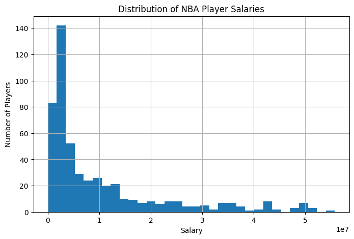

```python
plt.figure(figsize=(8,5))
plt.hist(full_data["Salary"].dropna(), bins=32)
plt.title("Distribution of NBA Player Salaries")
plt.xlabel("Salary")
plt.ylabel("Number of Players")
plt.grid(True)
plt.show()
```

The Histogram shows that NBA salaries are highly skewed. There are many players on low salary contracts while few superstars on high salary contracts. The histogram shows a great opportunity for Memphis to find a productive team member at a low cost, rather than only targeting high salary players

# Salary vs points graph

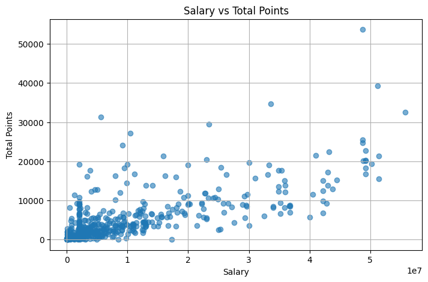

```python
plt.figure(figsize=(8,5))
plt.scatter(full_data["Salary"], full_data["points"], alpha=0.6)
plt.title("Salary vs Total Points")
plt.xlabel("Salary")
plt.ylabel("Total Points")
plt.grid(True)
plt.show()
```

The scatterplot shows that higher salaries are related to more points, but also shows that Memphis can aquire players with high scoring totals at a low cost.

Scoring is just a singular aspect of a players value. It ignores defence and efficiency and the impact that is not seen on the stat sheet.

# Team Payroll by salary cap tier

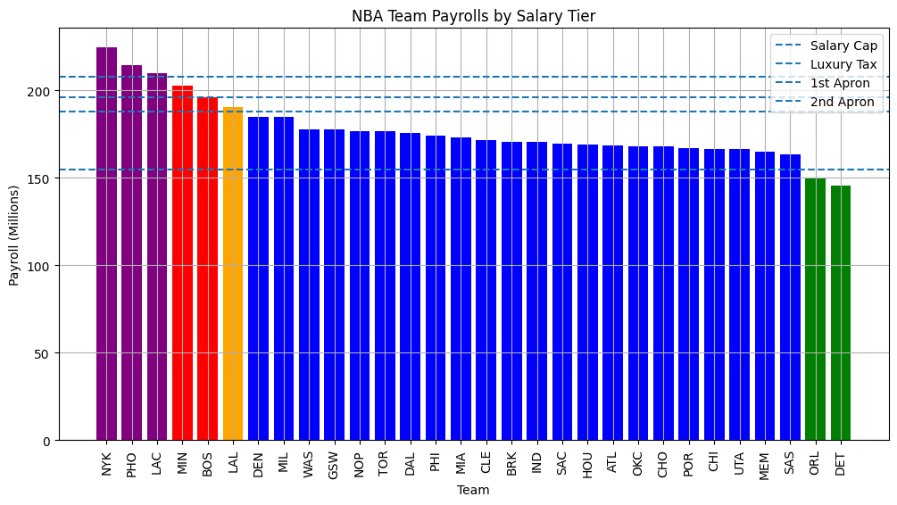

```python
color_map = {
    "1) Under Cap": "green",
    "2) Above Cap, Below Tax": "blue",
    "3) Tax, Below 1st Apron": "orange",
    "4) 1st Apron to 2nd Apron": "red",
    "5) Above 2nd Apron": "purple"
}

plt.figure(figsize=(12,6))
plt.bar(
    team_payroll["Team"],
    team_payroll["team_payroll_millions"],
    color=team_payroll["salary_group"].map(color_map)
)

plt.axhline(salary_cap / 1_000_000, linestyle="--", label="Salary Cap")
plt.axhline(luxury_tax / 1_000_000, linestyle="--", label="Luxury Tax")
plt.axhline(first_apron / 1_000_000, linestyle="--", label="1st Apron")
plt.axhline(second_apron / 1_000_000, linestyle="--", label="2nd Apron")

plt.title("NBA Team Payrolls by Salary Tier")
plt.xlabel("Team")
plt.ylabel("Payroll (Millions)")
plt.xticks(rotation=90)
plt.legend()
plt.grid(True)
plt.show()
```

This bar graph of NBA Team Payrolls by Salary Tier shows how Memphis compares to the rest of the league in payroll. Memphis is currently below the luxury tax and is one of the most finnacially flexible teams in the league

# Memphis Grizzlies Trade Targets Ananlysis

We build three progressively better models to find players Memphis could acquire.

```python
#Preserve Memphis Players by not removing them through the filters

df = full_data.copy()
df["salary_M"] = df["Salary"] / 1_000_000
df["min_pg"]   = df["minutes"] / df["gamesPlayed"]

for col in ["ws_48", "bpm", "ts_percent", "per", "vorp", "age"]:
    df[col] = pd.to_numeric(df[col], errors="coerce").fillna(0)

league_mask = (
    (df["gamesPlayed"] >= 20) &
    (df["minutes"] / df["gamesPlayed"] >= 18) &
    (df["Salary"] >= 5_000_000)
)

df = df[league_mask | (df["Team"] == "MEM")].copy()
df = df.drop_duplicates(subset=["full_name"], keep="first").copy()

salary_floor = 5.0
df["value_score"] = (
    df["ws_48"] * 10 +
    df["bpm"] +
    df["ts_percent"] * 5 +
    df["points_per_game"] * 0.3
) / df["salary_M"].clip(lower=salary_floor)

print(f"Total players in df: {len(df)}")
print(f"Memphis players in df: {len(df[df['Team'] == 'MEM'])}")
print("\nAll Memphis players confirmed in df:")
display(df[df["Team"] == "MEM"][["full_name","salary_M","gamesPlayed","value_score"]]
        .sort_values("salary_M", ascending=False).round(2))
```

```
Total players in df: 206
Memphis players in df: 18

All Memphis players confirmed in df:
```

|  | full_name | salary_M | gamesPlayed | value_score |
| --- | --- | --- | --- | --- |
| 354 | Ja Morant | 36.73 | 402 | 0.21 |
| 24 | Desmond Bane | 34.01 | 462 | 0.32 |
| 236 | Jaren Jackson | 25.26 | 504 | 0.17 |
| 17 | Marvin Bagley III | 12.50 | 460 | 0.68 |
| 100 | Brandon Clarke | 12.50 | 399 | 0.00 |
| 269 | Luke Kennard | 9.25 | 658 | 0.80 |
| 281 | John Konchar | 6.16 | 534 | 0.93 |
| 150 | Zach Edey | 5.76 | 96 | 1.38 |
| 123 | Johnny Davis | 5.29 | 172 | 0.67 |
| 4 | Santi Aldama | 3.96 | 364 | 1.63 |
| 571 | Vince Williams Jr. | 2.12 | 215 | 0.60 |
| 224 | Jay Huff | 2.09 | 254 | 1.18 |
| 398 | Scotty Pippen Jr. | 2.09 | 166 | 0.53 |
| 95 | Kennedy Chandler | 2.02 | 97 | -0.37 |
| 234 | GG Jackson | 1.89 | 185 | 0.99 |
| 547 | Jaylen Wells | 1.16 | 168 | 0.68 |
| 486 | Lamar Stevens | 0.62 | 343 | 0.44 |
| 131 | Mamadi Diakite | 0.46 | 176 | 1.81 |

League filters (games, minutes, salary) are applied only to non-Memphis players. All Grizzlies are kept even if they fail the requirements so they appear in every graph regardless of injury or sample size.

```python
if "Position" not in df.columns:
    df["Position"] = full_data["Position"]

affordable_targets = df[
    (df["Team"] != "MEM") &
    (df["Salary"] <= (luxury_tax - memphis_payroll))
].copy()

affordable_targets = affordable_targets.sort_values("value_score", ascending=False)

display(
    affordable_targets[[
        "full_name", "Team", "Position", "Salary",
        "points", "reboundsTotal", "assists", "value_score"
    ]].head(15)
)
```

|  | full_name | Team | Position | Salary | points | reboundsTotal | assists | value_score |
| --- | --- | --- | --- | --- | --- | --- | --- | --- |
| 358 | Trey Murphy III | NOP | Forward | 5159854 | 5187.0 | 1474.0 | 755.0 | 2.114803 |
| 143 | Andre Drummond | PHI | Center | 5000000 | 12835.0 | 12486.0 | 1299.0 | 1.850119 |
| 548 | Victor Wembanyama | SAS | Forward-Center | 12768960 | 4527.0 | 2106.0 | 677.0 | 1.808303 |
| 531 | Franz Wagner | ORL | Forward | 7007092 | 6736.0 | 1735.0 | 1291.0 | 1.764258 |
| 550 | Russell Westbrook | DEN | Guard | 5631296 | 31257.0 | 10246.0 | 11738.0 | 1.634513 |
| 103 | Donovan Clingan | POR | Center | 6836400 | 1465.0 | 1532.0 | 256.0 | 1.534018 |
| 302 | Dereck Lively II | DAL | Center | 5014560 | 1083.0 | 917.0 | 210.0 | 1.484745 |
| 416 | Payton Pritchard | BOS | Guard | 6696429 | 5219.0 | 1458.0 | 1521.0 | 1.434487 |
| 28 | Scottie Barnes | TOR | Guard-Forward | 10130980 | 6676.0 | 2870.0 | 1978.0 | 1.336749 |
| 537 | Cason Wallace | OKC | Guard | 5555880 | 2066.0 | 793.0 | 594.0 | 1.313942 |
| 217 | Chet Holmgren | OKC | Forward-Center | 10880640 | 3684.0 | 1854.0 | 435.0 | 1.310585 |
| 121 | Dyson Daniels | ATL | Guard | 6059520 | 2709.0 | 1498.0 | 1139.0 | 1.298203 |
| 175 | Josh Giddey | CHI | Guard | 8352367 | 5291.0 | 2742.0 | 2367.0 | 1.268877 |
| 141 | Ayo Dosunmu | CHI | Guard | 7000000 | 4187.0 | 1124.0 | 1232.0 | 1.232482 |
| 503 | Amen Thompson | HOU | Guard-Forward | 9249960 | 3300.0 | 1702.0 | 924.0 | 1.219553 |

# Improved Memphis Grizzlies Trade Targets

```python
# Improved value model

df = full_data.copy()
df["salary_M"] = df["Salary"] / 1_000_000
df["min_pg"]   = df["minutes"] / df["gamesPlayed"]

for col in ["ws_48", "bpm", "ts_percent", "per", "vorp", "age"]:
    df[col] = pd.to_numeric(df[col], errors="coerce").fillna(0)

if "Position" not in df.columns:
    df["Position"] = df.apply(get_position, axis=1)

league_mask = (
    (df["gamesPlayed"] >= 20) &
    (df["minutes"] / df["gamesPlayed"] >= 18) &
    (df["Salary"] >= 5_000_000)
)
df = df[league_mask | (df["Team"] == "MEM")].copy()
df = df.drop_duplicates(subset=["full_name"], keep="first").copy()

salary_floor = 5.0
df["value_score"] = (
    df["ws_48"] * 10 +
    df["bpm"] +
    df["ts_percent"] * 5 +
    df["points_per_game"] * 0.3
) / df["salary_M"].clip(lower=salary_floor)

print(f"Players in df: {len(df)}")
print(f"Memphis players: {len(df[df['Team'] == 'MEM'])}")

display(df[["full_name","Team","Position","salary_M",
            "ws_48","bpm", "age","value_score"]]
        .sort_values("value_score", ascending=False).head(15).round(3))
```

```
Players in df: 206
Memphis players: 18
```

|  | full_name | Team | Position | salary_M | ws_48 | bpm | age | value_score |
| --- | --- | --- | --- | --- | --- | --- | --- | --- |
| 358 | Trey Murphy III | NOP | Forward | 5.160 | 0.123 | 2.4 | 25.0 | 2.115 |
| 143 | Andre Drummond | PHI | Center | 5.000 | 0.170 | 1.3 | 28.0 | 1.850 |
| 131 | Mamadi Diakite | MEM | Forward | 0.464 | 0.168 | 3.5 | 27.0 | 1.809 |
| 548 | Victor Wembanyama | SAS | Forward-Center | 12.769 | 0.257 | 10.7 | 22.0 | 1.808 |
| 531 | Franz Wagner | ORL | Forward | 7.007 | 0.134 | 2.5 | 24.0 | 1.764 |
| 550 | Russell Westbrook | DEN | Guard | 5.631 | 0.044 | 0.2 | 34.0 | 1.635 |
| 4 | Santi Aldama | MEM | Forward-Center | 3.961 | 0.092 | 1.7 | 25.0 | 1.633 |
| 103 | Donovan Clingan | POR | Center | 6.836 | 0.197 | 3.0 | 21.0 | 1.534 |
| 302 | Dereck Lively II | DAL | Center | 5.015 | 0.127 | 0.6 | 21.0 | 1.485 |
| 416 | Payton Pritchard | BOS | Guard | 6.696 | 0.160 | 2.3 | 28.0 | 1.434 |
| 150 | Zach Edey | MEM | Center | 5.757 | 0.134 | 0.5 | 23.0 | 1.377 |
| 28 | Scottie Barnes | TOR | Guard-Forward | 10.131 | 0.140 | 4.2 | 24.0 | 1.337 |
| 537 | Cason Wallace | OKC | Guard | 5.556 | 0.122 | 1.2 | 22.0 | 1.314 |
| 217 | Chet Holmgren | OKC | Forward-Center | 10.881 | 0.219 | 4.2 | 23.0 | 1.311 |
| 121 | Dyson Daniels | ATL | Guard | 6.060 | 0.126 | 1.3 | 22.0 | 1.298 |

Salary alone cannot determine a players true value. The context of a players salary is very important.

# Realistic trade targets for the Memphis Grizzlies

After building an improved value model, we refine our analysis to focus on players Memphis could realistically acquire.

We apply additional constraints:

- Mid-tier salaries ($8M–$25M)
- Non-Memphis players
- Players with real playing time (40+ games)
- Exclude superstars (BPM ≤ 5)
- Focus on experienced players (age 25+)

This ensures our results reflect real trade scenarios rather than theoretical value.

```python
realistic_targets = df[
    (df["Team"] != "MEM") &
    (df["salary_M"] >= 8) &
    (df["salary_M"] <= 25) &
    (df["gamesPlayed"] >= 40) &
    (df["bpm"] <= 5) &
    (df["age"] >= 25)
].copy()

realistic_targets = realistic_targets.sort_values("value_score", ascending=False)

display(realistic_targets[[
    "full_name", "Team", "Position", "salary_M",
    "ws_48", "bpm", "ts_percent", "points_per_game", "value_score"
]].head(15).round(3))
```

|  | full_name | Team | Position | salary_M | ws_48 | bpm | ts_percent | points_per_game | value_score |
| --- | --- | --- | --- | --- | --- | --- | --- | --- | --- |
| 394 | Gary Payton | GSW | Guard | 9.130 | 0.125 | 0.3 | 0.701 | 15.796 | 1.073 |
| 326 | T.J. McConnell | IND | Guard | 9.300 | 0.132 | 2.5 | 0.567 | 7.397 | 0.954 |
| 219 | Al Horford | BOS | Forward-Center | 9.500 | 0.105 | 1.6 | 0.554 | 11.877 | 0.946 |
| 260 | Tre Jones | CHI | Guard | 9.104 | 0.155 | 1.5 | 0.617 | 8.147 | 0.942 |
| 422 | Austin Reaves | LAL | Guard | 12.976 | 0.153 | 2.8 | 0.641 | 14.706 | 0.921 |
| 110 | Mike Conley | MIN | Guard | 9.976 | 0.130 | 0.9 | 0.583 | 12.699 | 0.895 |
| 188 | Jeff Green | HOU | Forward | 8.000 | 0.104 | -0.1 | 0.590 | 10.330 | 0.874 |
| 9 | Kyle Anderson | MIA | Guard-Forward | 8.780 | 0.135 | 1.5 | 0.538 | 5.985 | 0.835 |
| 167 | Daniel Gafford | DAL | Forward-Center | 13.394 | 0.205 | 2.6 | 0.731 | 8.552 | 0.812 |
| 13 | Deni Avdija | POR | Forward | 15.625 | 0.152 | 4.3 | 0.600 | 12.333 | 0.801 |
| 364 | Larry Nance | ATL | Forward | 11.205 | 0.104 | -0.1 | 0.590 | 16.961 | 0.801 |
| 433 | Mitchell Robinson | NYK | Forward-Center | 14.318 | 0.236 | 3.5 | 0.676 | 6.893 | 0.790 |
| 87 | Alex Caruso | OKC | Guard | 9.890 | 0.120 | 1.9 | 0.540 | 6.262 | 0.776 |
| 211 | Buddy Hield | GSW | Guard | 8.780 | 0.060 | -1.0 | 0.568 | 13.749 | 0.748 |
| 315 | Naji Marshall | DAL | Forward | 8.571 | 0.095 | -0.6 | 0.592 | 8.652 | 0.689 |

Without significant filters on the players targeted unrealsitic trade scenarios would be predicted.

# Contract Quality Classification

- group contracts into salary bands
- Assess wether player are overpriced, underpriced, valued fairly according to advaced stats:

```python
def salary_band(sal_m):
    if sal_m < 5:
        return "Min/Cheap (<$5M)"
    elif sal_m < 15:
        return "Mid ($5-15M)"
    elif sal_m < 30:
        return "Max-Adjacent ($15-30M)"
    else:
        return "Max ($30M+)"

df["salary_band"] = df["salary_M"].apply(salary_band)

df["contract_quality"] = pd.qcut(
    df["value_score"],
    q=3,
    labels=["Overpaid", "Fair", "Good Value"],
    duplicates="drop"
)

print("Contract Quality Distribution:")
display(df["contract_quality"].value_counts())

print("Cross-tab: Contract Quality by Salary Band")
display(pd.crosstab(df["salary_band"], df["contract_quality"]))
```

```
Contract Quality Distribution:
```

| contract_quality | count |
| --- | --- |
| Overpaid | 69 |
| Good Value | 69 |
| Fair | 68 |

**dtype:** int64

```
Cross-tab: Contract Quality by Salary Band
```

| contract_quality salary_band | Overpaid | Fair | Good Value |
| --- | --- | --- | --- |
| Max ($30M+) | 27 | 21 | 1 |
| Max-Adjacent ($15-30M) | 27 | 29 | 2 |
| Mid ($5-15M) | 14 | 16 | 60 |
| Min/Cheap (<$5M) | 1 | 2 | 6 |

A problem is noticed as the higher contract players are seen as overpaid and the lower value contracts are seen as good value.

# Best trade targets for Memphis

- Table displays:
  - salary under 30m (to stay under tax apron) and above 14 million to exclude rookies and superstar veterans
  - Value Score in the top 40%
  - Contracts labeled Good Value

```python
targets = df[
    (df["Team"] != "MEM") &
    (df["salary_M"] <= 30) &
    (df["salary_M"] >= 14) & #excludes rookie contracts
    (df["gamesPlayed"] >= 40) &
    (df["value_score"] >= df["value_score"].quantile(0.60)) &
    (df["contract_quality"] == "Good Value")
].sort_values("value_score", ascending=False)

target_cols = [
    "full_name", "Team", "Position", "salary_M",
    "points_per_game", "rebounds_per_game", "assists_per_game",
    "value_score", "salary_band", "contract_quality"
]

print(f"Top realistic trade targets ({len(targets)} players found):")
display(targets[target_cols].head(15).round(2))
```

```
Top realistic trade targets (4 players found):
```

|  | full_name | Team | Position | salary_M | points_per_game | rebounds_per_game | assists_per_game | value_score | salary_band | contract_quality |
| --- | --- | --- | --- | --- | --- | --- | --- | --- | --- | --- |
| 13 | Deni Avdija | POR | Forward | 15.62 | 12.33 | 5.86 | 3.17 | 0.80 | Max-Adjacent ($15-30M) | Good Value |
| 433 | Mitchell Robinson | NYK | Forward-Center | 14.32 | 6.89 | 7.50 | 0.61 | 0.79 | Mid ($5-15M) | Good Value |
| 101 | Jordan Clarkson | UTA | Guard | 14.09 | 14.13 | 2.99 | 2.51 | 0.65 | Mid ($5-15M) | Good Value |
| 6 | Grayson Allen | PHO | Guard | 15.62 | 9.90 | 2.70 | 1.91 | 0.59 | Max-Adjacent ($15-30M) | Good Value |

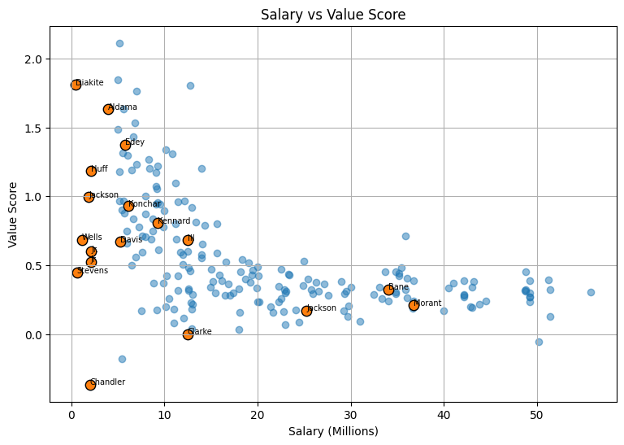

```python
plt.figure(figsize=(9, 6))
plt.scatter(df["salary_M"], df["value_score"], alpha=0.5)

griz = df[df["Team"] == "MEM"]
plt.scatter(griz["salary_M"], griz["value_score"], s=80, edgecolors="black")

for _, row in griz.iterrows():
    plt.annotate(
        row["full_name"].split()[-1],
        (row["salary_M"], row["value_score"]),
        fontsize=7
    )

plt.title("Salary vs Value Score")
plt.xlabel("Salary (Millions)")
plt.ylabel("Value Score")
plt.grid(True)
plt.show()
```

NBA star players are undervalued in this model while role players are overvalued. Players like Ja Morant, Desmond Bane, and Jaren Jackson Jr. the 3 lower orange points are the Grizzlies three best players but under this model they are seen viewed that way as with every other player with similar salaires compared to them.

This suggests that the model may undervalue star players whose impact is not fully captured by the selected metrics. For Memphis, this means decisions should not rely solely on the model but also consider real-world player importance.

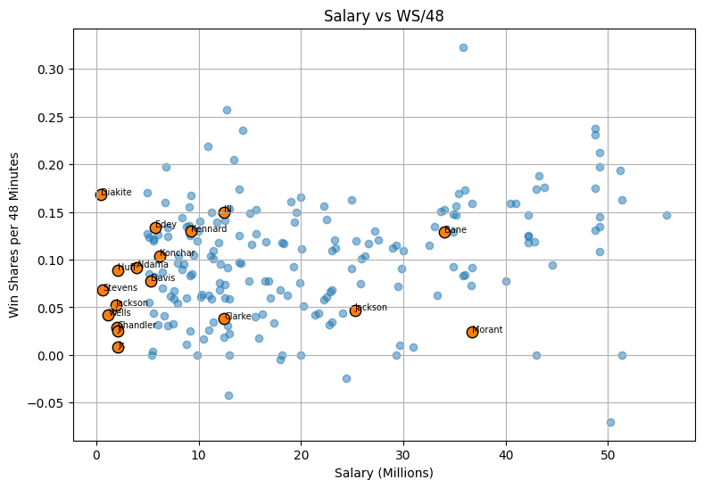

```python
plt.figure(figsize=(9, 6))
plt.scatter(df["salary_M"], df["ws_48"], alpha=0.5)

griz = df[df["Team"] == "MEM"]
plt.scatter(griz["salary_M"], griz["ws_48"], s=80, edgecolors="black")

for _, row in griz.iterrows():
    plt.annotate(
        row["full_name"].split()[-1],
        (row["salary_M"], row["ws_48"]),
        fontsize=7
    )

plt.title("Salary vs WS/48")
plt.xlabel("Salary (Millions)")
plt.ylabel("Win Shares per 48 Minutes")
plt.grid(True)
plt.show()
```

## Advanced Analysis: Composite Value Score and Salary-Matched Trades

The sections below represent a significant methodological upgrade. Rather than dividing raw stats by salary, we build a composite score from four advanced metrics weighted the way an NBA front office would use them. We then apply the NBA's actual 125% salary matching rule to identify legally executable trades targeting Memphis's specific positional weaknesses.

```python
# df2 — Composite value score, Memphis always preserved

df2 = full_data.copy()
df2["salary_M"] = df2["Salary"] / 1_000_000
df2["Position"] = df2.apply(get_position, axis=1)

for col in ["vorp", "ws_48", "bpm", "per", "ts_percent", "age"]:
    df2[col] = pd.to_numeric(df2[col], errors="coerce").fillna(0)

league_mask2 = (
    (df2["gamesPlayed"] >= 20) &
    (df2["minutes"] / df2["gamesPlayed"] >= 18) &
    (df2["Salary"] >= 5_000_000)
)
df2 = df2[league_mask2 | (df2["Team"] == "MEM")].copy()
df2 = df2.drop_duplicates(subset=["full_name"], keep="first").copy()

df2["composite_score"] = (
    0.35 * df2["vorp"] +
    0.30 * df2["ws_48"] * 10 +
    0.20 * df2["bpm"] +
    0.15 * (df2["per"] / 15)
)

salary_floor = 8.0
df2["adv_value_score"] = df2["composite_score"] / df2["salary_M"].clip(lower=salary_floor)

griz2 = df2[df2["Team"] == "MEM"].copy()
print(f"Total players in df2: {len(df2)}")
print(f"Memphis players in df2: {len(griz2)}")
print("\nAll Memphis players with composite scores:")
display(griz2[["full_name","salary_M","composite_score","adv_value_score","Position"]]
        .sort_values("salary_M", ascending=False).round(3))
```

```
Total players in df2: 206
Memphis players in df2: 18

All Memphis players with composite scores:
```

|  | full_name | salary_M | composite_score | adv_value_score | Position |
| --- | --- | --- | --- | --- | --- |
| 354 | Ja Morant | 36.726 | -0.027 | -0.001 | Guard |
| 24 | Desmond Bane | 34.005 | 1.641 | 0.048 | Guard |
| 236 | Jaren Jackson | 25.258 | 0.353 | 0.014 | Guard |
| 17 | Marvin Bagley III | 12.500 | 1.092 | 0.087 | Forward |
| 100 | Brandon Clarke | 12.500 | -0.743 | -0.059 | Forward |
| 269 | Luke Kennard | 9.250 | 0.860 | 0.093 | Guard |
| 281 | John Konchar | 6.165 | 0.908 | 0.114 | Guard |
| 150 | Zach Edey | 5.757 | 0.779 | 0.097 | Center |
| 123 | Johnny Davis | 5.291 | 0.392 | 0.049 | Guard |
| 4 | Santi Aldama | 3.961 | 1.164 | 0.146 | Forward-Center |
| 571 | Vince Williams Jr. | 2.121 | 0.001 | 0.000 | Guard |
| 224 | Jay Huff | 2.088 | 0.884 | 0.110 | Center |
| 398 | Scotty Pippen Jr. | 2.088 | -0.338 | -0.042 | Guard |
| 95 | Kennedy Chandler | 2.020 | -1.028 | -0.128 | Guard |
| 234 | GG Jackson | 1.892 | 0.142 | 0.018 | Forward |
| 547 | Jaylen Wells | 1.157 | -0.554 | -0.069 | Forward |
| 486 | Lamar Stevens | 0.624 | -0.090 | -0.011 | Forward |
| 131 | Mamadi Diakite | 0.464 | 1.390 | 0.174 | Forward |

Rather than relying on a single stat, we weight four advanced metrics the way a front office would prioritize them.

- VORP and WS reflect actual winning contribution
- BPM captures two-way impact
- PER captures per-minute efficiency.
- We use WS/48 since it represents a player w/s per 48 minutes (the length of a full NBA game)

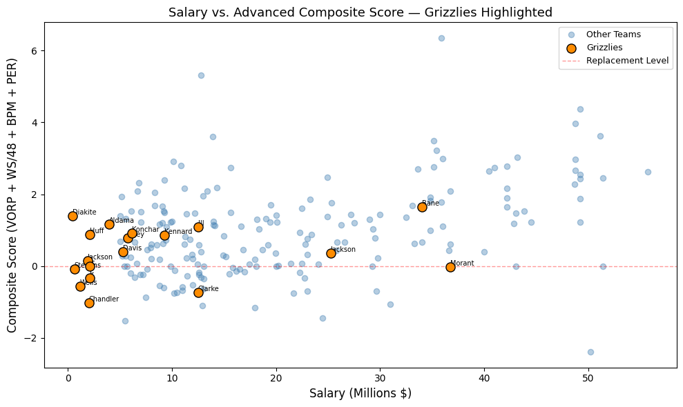

```python
#Salary vs. Composite Score (Advanced stats)

fig, ax = plt.subplots(figsize=(10, 6))

non_griz2 = df2[df2["Team"] != "MEM"]
griz2 = df2[df2["Team"] == "MEM"]

ax.scatter(non_griz2["salary_M"], non_griz2["composite_score"],
           alpha=0.4, s=35, color="steelblue", label="Other Teams")
ax.scatter(griz2["salary_M"], griz2["composite_score"],
           color="darkorange", edgecolors="black", s=90, zorder=5, label="Grizzlies")

for _, row in griz2.iterrows():
    ax.annotate(row["full_name"].split()[-1],
                (row["salary_M"], row["composite_score"]),
                fontsize=7, ha="left", va="bottom")

ax.axhline(0, color="red", linestyle="--", alpha=0.4, linewidth=1, label="Replacement Level")
ax.set_xlabel("Salary (Millions $)", fontsize=12)
ax.set_ylabel("Composite Score (VORP + WS/48 + BPM + PER)", fontsize=12)
ax.set_title("Salary vs. Advanced Composite Score — Grizzlies Highlighted", fontsize=13)
ax.legend(fontsize=9)
plt.tight_layout()
plt.show()
```

Players in the top-left are the most undervalued. Theese players have advanced performance at a low cost. Grizzlies are highlighted so we can see how Memphis compares to the rest of the league. The red dashed line marks replacement level (composite score = 0); anyone below it is performing below what a minimum-salary player would provide.

The Grizzlies' players above the replacement level are high-value players that the Grizzlies could try to trade for other high-value players. Players below the replacement level line are players at or below the replacement line are players that the Grizzlies should try to trade for higher value players.

Notable players to trade would would be Ja Morant, Desmond Bane, Jaren Jackson Jr., Desmond Bane, and Brandon Clarke. Theese four players makeup the four largest contracts on the Memphis Grizzlies.

- Ja Morant and Brandon Clark are playing at or below the replacement level line so the Grizzlies should trade them for higher value players
- Jaren Jackson Jr and Desmond Bane are playing above the replacement level line and could be traded away to other teams for many assets such as picks and players

This graph helps identify potential trade targets, but it also highlights a limitation: many high-performing players are not realistically available. This reinforces the need to combine performance analysis with trade feasibility.

# Trade Analysis 4 Steps

1. Identify Tradeable Grizzlies Players Using 125% CBA Trade Rule
2. Identify Memphis positional needs
3. Find salary-matched trade targets at positions Memphis needs
4. Visualize top trade targets

```python
# step 1: Identify Tradeable Grizzlies Players Using 125% CBA Trade Rule

def trade_window(salary_m):
    low  = round(salary_m * 0.80, 2)
    high = round(salary_m * 1.25 + 0.1, 2)
    return low, high

griz2 = df2[df2["Team"] == "MEM"].copy()
team_median_score = griz2["composite_score"].median()

tradeable = griz2[griz2["composite_score"] <= team_median_score].copy()
tradeable["trade_min_M"] = tradeable["salary_M"].apply(lambda x: trade_window(x)[0])
tradeable["trade_max_M"] = tradeable["salary_M"].apply(lambda x: trade_window(x)[1])

print(f"Team median composite score: {team_median_score:.3f}")
print(f"Grizzlies players available in trades: {len(tradeable)}\n")
display(tradeable[["full_name","salary_M","composite_score",
                    "trade_min_M","trade_max_M"]]
        .sort_values("salary_M", ascending=False).round(2))
```

```
Team median composite score: 0.372
Grizzlies players available in trades: 9
```

|  | full_name | salary_M | composite_score | trade_min_M | trade_max_M |
| --- | --- | --- | --- | --- | --- |
| 354 | Ja Morant | 36.73 | -0.03 | 29.38 | 46.01 |
| 236 | Jaren Jackson | 25.26 | 0.35 | 20.21 | 31.67 |
| 100 | Brandon Clarke | 12.50 | -0.74 | 10.00 | 15.72 |
| 571 | Vince Williams Jr. | 2.12 | 0.00 | 1.70 | 2.75 |
| 398 | Scotty Pippen Jr. | 2.09 | -0.34 | 1.67 | 2.71 |
| 95 | Kennedy Chandler | 2.02 | -1.03 | 1.62 | 2.62 |
| 234 | GG Jackson | 1.89 | 0.14 | 1.51 | 2.46 |
| 547 | Jaylen Wells | 1.16 | -0.55 | 0.93 | 1.55 |
| 486 | Lamar Stevens | 0.62 | -0.09 | 0.50 | 0.88 |

A real front office thinks in terms of:

1. Which Grizzlies players are realistic trade peices?
2. What positions does Memphis need?

The 125% CBA rule: receiving team can take back at most

- 125% + $100k of the salary they send out.

```python
# Step 2: Identify Memphis positional needs
# Weakest positions by composite score where upgrades help most

griz_by_pos = griz2.groupby("Position")["composite_score"].mean().sort_values()
print("Grizzlies average composite score by position (lowest = biggest need):\n")
print(griz_by_pos.round(3))

need_positions = griz_by_pos.index[:2].tolist()
print(f"\nTop positional needs identified: {need_positions}")
```

```
Grizzlies average composite score by position (lowest = biggest need):

Position
Forward           0.206
Guard             0.307
Center            0.831
Forward-Center    1.164
Name: composite_score, dtype: float64

Top positional needs identified: ['Forward', 'Guard']
```

```python
# Step 3: Find salary-matched trade targets at positions Memphis needs

non_griz2 = df2[df2["Team"] != "MEM"].copy()
trade_results = []

for _, gp in tradeable.iterrows():
    lo, hi = gp["trade_min_M"], gp["trade_max_M"]

    matches = non_griz2[
        (non_griz2["salary_M"] >= lo) &
        (non_griz2["salary_M"] <= hi) &
        (non_griz2["Position"].isin(need_positions)) &
        (non_griz2["composite_score"] > 0) &
        (non_griz2["composite_score"] < 3.0) &
        (non_griz2["gamesPlayed"] >= 30)
    ].copy()

    matches["trade_away"]       = gp["full_name"]
    matches["trade_away_sal_M"] = gp["salary_M"]
    matches["trade_away_score"] = gp["composite_score"]
    trade_results.append(matches)

trade_df = pd.concat(trade_results, ignore_index=True) if trade_results else pd.DataFrame()

cols = ["trade_away", "trade_away_sal_M", "trade_away_score",
        "full_name", "Team", "Position", "age",
        "salary_M", "composite_score", "bpm", "vorp"]

print(f"Realistic salary-matched trade targets found: {len(trade_df)}\n")
trade_df[cols].sort_values("composite_score", ascending=False)\
    .drop_duplicates(subset="full_name").head(20).round(2)
```

```
Realistic salary-matched trade targets found: 47
```

|  | trade_away | trade_away_sal_M | trade_away_score | full_name | Team | Position | age | salary_M | composite_score | bpm | vorp |
| --- | --- | --- | --- | --- | --- | --- | --- | --- | --- | --- | --- |
| 40 | Ja Morant | 36.73 | -0.03 | Jamal Murray | DEN | Guard | 28.0 | 36.02 | 2.99 | 4.1 | 4.1 |
| 28 | Ja Morant | 36.73 | -0.03 | Anthony Edwards | MIN | Guard | 24.0 | 42.18 | 2.78 | 4.5 | 3.5 |
| 27 | Ja Morant | 36.73 | -0.03 | LaMelo Ball | CHO | Guard | 24.0 | 35.15 | 2.77 | 4.7 | 3.4 |
| 36 | Ja Morant | 36.73 | -0.03 | Kyrie Irving | DAL | Guard | 30.0 | 41.00 | 2.75 | 4.1 | 3.5 |
| 1 | Brandon Clarke | 12.50 | -0.74 | Deni Avdija | POR | Forward | 25.0 | 15.62 | 2.74 | 4.3 | 3.5 |
| 33 | Ja Morant | 36.73 | -0.03 | James Harden | LAC | Guard | 36.0 | 33.65 | 2.70 | 3.9 | 3.6 |
| 13 | Jaren Jackson | 25.26 | 0.35 | Jalen Brunson | NYK | Guard | 29.0 | 24.96 | 2.46 | 3.1 | 3.3 |
| 32 | Ja Morant | 36.73 | -0.03 | Tyrese Haliburton | IND | Guard | 21.0 | 42.18 | 2.16 | 2.6 | 3.1 |
| 45 | Ja Morant | 36.73 | -0.03 | Zion Williamson | NOP | Forward | 25.0 | 36.73 | 2.09 | 2.9 | 2.3 |
| 8 | Brandon Clarke | 12.50 | -0.74 | Austin Reaves | LAL | Guard | 27.0 | 12.98 | 1.96 | 2.8 | 2.1 |
| 43 | Ja Morant | 36.73 | -0.03 | Pascal Siakam | IND | Forward | 29.0 | 42.18 | 1.89 | 1.9 | 2.7 |
| 41 | Ja Morant | 36.73 | -0.03 | Michael Porter Jr. | DEN | Forward | 27.0 | 35.86 | 1.78 | 3.0 | 2.1 |
| 17 | Jaren Jackson | 25.26 | 0.35 | Tobias Harris | DET | Forward | 26.0 | 25.37 | 1.76 | 1.6 | 2.6 |
| 20 | Jaren Jackson | 25.26 | 0.35 | Cameron Johnson | BRK | Forward | 26.0 | 22.50 | 1.61 | 2.6 | 1.4 |
| 0 | Brandon Clarke | 12.50 | -0.74 | Grayson Allen | PHO | Guard | 30.0 | 15.62 | 1.49 | 2.1 | 1.5 |
| 2 | Brandon Clarke | 12.50 | -0.74 | Paolo Banchero | ORL | Forward | 23.0 | 12.16 | 1.48 | 1.4 | 2.1 |
| 46 | Ja Morant | 36.73 | -0.03 | Trae Young | ATL | Guard | 27.0 | 43.03 | 1.47 | 2.8 | 0.5 |
| 6 | Brandon Clarke | 12.50 | -0.74 | Brandon Miller | CHO | Forward | 23.0 | 11.42 | 1.44 | 1.6 | 1.8 |
| 11 | Jaren Jackson | 25.26 | 0.35 | Miles Bridges | CHO | Forward | 27.0 | 27.17 | 1.43 | 1.1 | 1.9 |
| 19 | Jaren Jackson | 25.26 | 0.35 | Jrue Holiday | BOS | Guard | 35.0 | 30.00 | 1.43 | 1.9 | 1.6 |

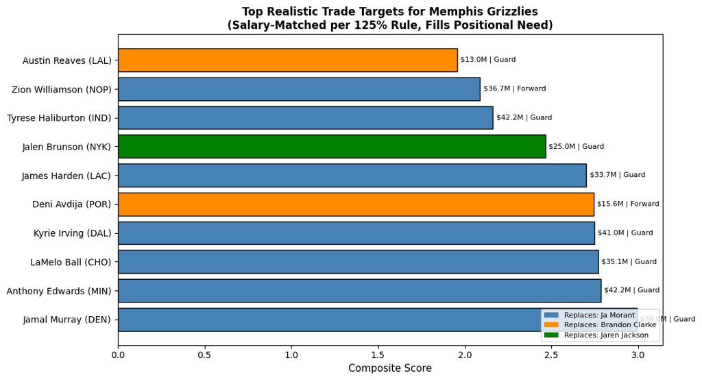

```python
# Step 4: Visualize top trade targets
# bars colored by which grizzly they would replace

if not trade_df.empty:
    top10 = trade_df.sort_values("composite_score", ascending=False)\
        .drop_duplicates(subset="full_name").head(10)

    fig, ax = plt.subplots(figsize=(11, 6))

    unique_griz = top10["trade_away"].unique()
    palette = ["steelblue", "darkorange", "green", "red", "purple"]
    color_map = {name: palette[i % len(palette)] for i, name in enumerate(unique_griz)}
    bar_colors = [color_map[g] for g in top10["trade_away"]]

    bars = ax.barh(
        top10["full_name"] + " (" + top10["Team"] + ")",
        top10["composite_score"],
        color=bar_colors, edgecolor="black"
    )

    for bar, (_, row) in zip(bars, top10.iterrows()):
        ax.text(bar.get_width() + 0.02,
                bar.get_y() + bar.get_height() / 2,
                f"${row['salary_M']:.1f}M | {row['Position']}",
                va="center", fontsize=8)

    from matplotlib.patches import Patch
    legend_elements = [Patch(facecolor=color_map[g], label=f"Replaces: {g}")
                       for g in unique_griz]
    ax.legend(handles=legend_elements, fontsize=8, loc="lower right")

    ax.set_xlabel("Composite Score", fontsize=11)
    ax.set_title(
        "Top Realistic Trade Targets for Memphis Grizzlies\n"
        "(Salary-Matched per 125% Rule, Fills Positional Need)",
        fontsize=12, fontweight="bold"
    )
    ax.axvline(0, color="black", linewidth=0.8, linestyle="--")
    plt.tight_layout()
    plt.show()
else:
    print("No targets found — check position filter or salary window.")
```

A pattern displayed through this graph is that many of the best positional upgrades come at the guard position. The best positional upgrade for the grizlies would be to trade away superstar Ja Morant for another superstar gaurd. This graph shows a limitation of the model as it ignores the fact that The majority of NBA teams are unwilling to trade away their franchise player. The value of Ja Morant in the model ignores features that are not present in data, Ja's personality. Ja Morant has had countless off the court problems that plummet his value.

The salary matching requirements also display the reality that aquiring a superstar level player requires your team to trade away a super star player. The model ignores the possibility of trading multiple players for one and trading away draft capital.

The roster upgrades modeled ignore factortors beyond the data such as teams strategy, player roles and willingness to trade away their players.

- not every team is located in a city that is desireable and many teams do not have the luxury of making high impact trades as the NBA is a player dominated league and superstar players have a significant say on where they are traded. Memphis is not a city where many superstar players would like to play

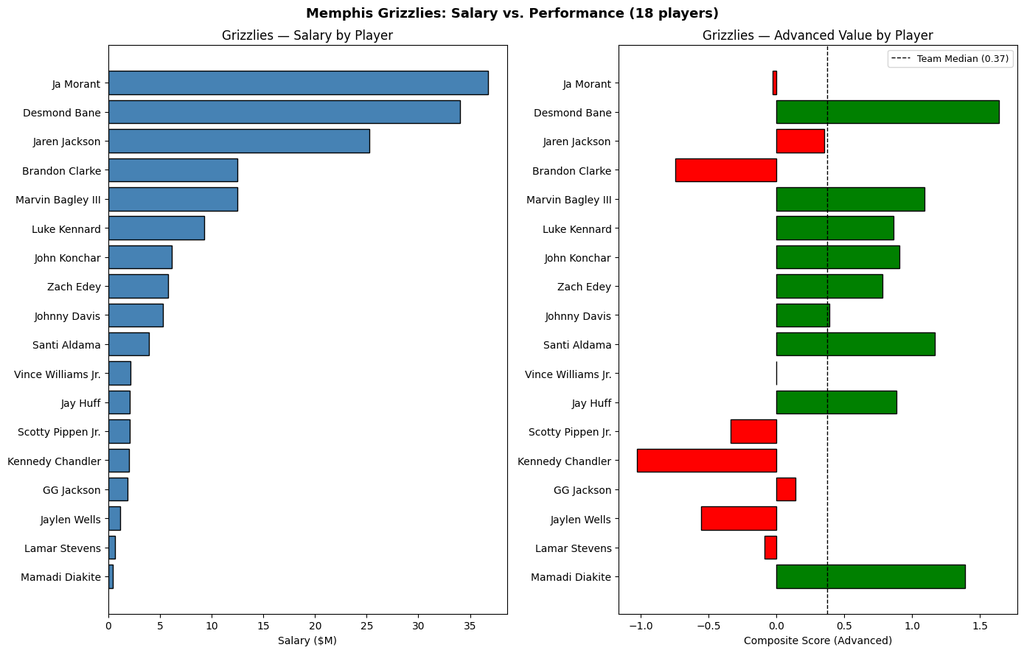

```
Players shown: 18
```

|  | full_name | salary_M | composite_score | Position | gamesPlayed |
| --- | --- | --- | --- | --- | --- |
| 354 | Ja Morant | 36.726 | -0.027 | Guard | 402 |
| 24 | Desmond Bane | 34.005 | 1.641 | Guard | 462 |
| 236 | Jaren Jackson | 25.258 | 0.353 | Guard | 504 |
| 17 | Marvin Bagley III | 12.500 | 1.092 | Forward | 460 |
| 100 | Brandon Clarke | 12.500 | -0.743 | Forward | 399 |
| 269 | Luke Kennard | 9.250 | 0.860 | Guard | 658 |
| 281 | John Konchar | 6.165 | 0.908 | Guard | 534 |
| 150 | Zach Edey | 5.757 | 0.779 | Center | 96 |
| 123 | Johnny Davis | 5.291 | 0.392 | Guard | 172 |
| 4 | Santi Aldama | 3.961 | 1.164 | Forward-Center | 364 |
| 571 | Vince Williams Jr. | 2.121 | 0.001 | Guard | 215 |
| 224 | Jay Huff | 2.088 | 0.884 | Center | 254 |
| 398 | Scotty Pippen Jr. | 2.088 | -0.338 | Guard | 166 |
| 95 | Kennedy Chandler | 2.020 | -1.028 | Guard | 97 |
| 234 | GG Jackson | 1.892 | 0.142 | Forward | 185 |
| 547 | Jaylen Wells | 1.157 | -0.554 | Forward | 168 |
| 486 | Lamar Stevens | 0.624 | -0.090 | Forward | 343 |
| 131 | Mamadi Diakite | 0.464 | 1.390 | Forward | 176 |

```python
# EDA graph 3— Memphis Grizzlies: Salary vs. Composite Score

griz2 = df2[df2["Team"] == "MEM"].copy()
griz2_sorted = griz2.sort_values("salary_M", ascending=True)

fig, axes = plt.subplots(1, 2, figsize=(14, max(6, len(griz2_sorted) * 0.5)))

axes[0].barh(griz2_sorted["full_name"], griz2_sorted["salary_M"],
             color="steelblue", edgecolor="black")
axes[0].set_xlabel("Salary ($M)")
axes[0].set_title("Grizzlies — Salary by Player")

med = griz2_sorted["composite_score"].median()
bar_colors = ["green" if v >= med else "red"
              for v in griz2_sorted["composite_score"]]
axes[1].barh(griz2_sorted["full_name"], griz2_sorted["composite_score"],
             color=bar_colors, edgecolor="black")
axes[1].axvline(med, color="black", linestyle="--", linewidth=1,
                label=f"Team Median ({med:.2f})")
axes[1].set_xlabel("Composite Score (Advanced)")
axes[1].set_title("Grizzlies — Advanced Value by Player")
axes[1].legend(fontsize=9)

plt.suptitle(f"Memphis Grizzlies: Salary vs. Performance ({len(griz2_sorted)} players)",
             fontsize=13, fontweight="bold")
plt.tight_layout()
plt.show()

print(f"\nPlayers shown: {len(griz2_sorted)}")
display(griz2_sorted[["full_name","salary_M","composite_score","Position","gamesPlayed"]]
        .sort_values("salary_M", ascending=False).round(3))
```

The chart above displays two charts side by side: Grizzlies Salary by Player and Grizzlies Advanced Value by player.

The Salary by Player chart displays that a significant concentration of the memphis Grizzlies payroll is taken up by three players: Ja Morant, Desmond Bane, and Jaren Jackson Jr.

Looking at the Adavanced Value by Player graph we can see that of the three highest paid players on the Grizzlies only one of them has a value score above the team mean, Desmond Bane. Ja Morant, despite having the highest salary, appears closer to average in this model, which may reflect limitations in the metric , missed games , or that he is low performing player compared to his salary.

The mid tier contract players such as Santi Aldama and Luke Kennard show immense value suggesting that role players are an efficient use of salary, boost depth, and can provide serious value.

Players that fall well below the median line such as Brandon Clarke and Kennedy chandler can be seen as players underperforming. Theese players can be viewed as potential canidates.

Overall this chart displays that the Memphis Grizzlies have potential trade candidates across their top and bottom salaries as their are players undperforming across all salaies.

```python
# Positional Breakdown of Advanced Stats


pos_stats = df2[df2["Position"].notna() & (df2["Position"] != "Unknown")].groupby("Position").agg(
    avg_salary_M   = ("salary_M",       "mean"),
    avg_composite  = ("composite_score", "mean"),
    avg_age        = ("age",             "mean"),
    avg_bpm        = ("bpm",             "mean"),
    avg_vorp       = ("vorp",            "mean"),
    player_count   = ("full_name",       "count")
).round(2).sort_values("avg_composite", ascending=False)

print("League-Wide Advanced Stats by Position:")
display(pos_stats)
```

```
League-Wide Advanced Stats by Position:
```

| Position | avg_salary_M | avg_composite | avg_age | avg_bpm | avg_vorp | player_count |
| --- | --- | --- | --- | --- | --- | --- |
| Forward-Center | 23.94 | 1.69 | 26.24 | 2.20 | 1.82 | 21 |
| Guard | 20.35 | 0.96 | 27.31 | 0.45 | 1.25 | 84 |
| Center | 17.45 | 0.87 | 20.33 | 0.58 | 0.85 | 21 |
| Forward | 19.12 | 0.71 | 27.40 | -0.12 | 0.88 | 55 |
| Guard-Forward | 20.58 | 0.71 | 25.48 | -0.15 | 0.92 | 25 |

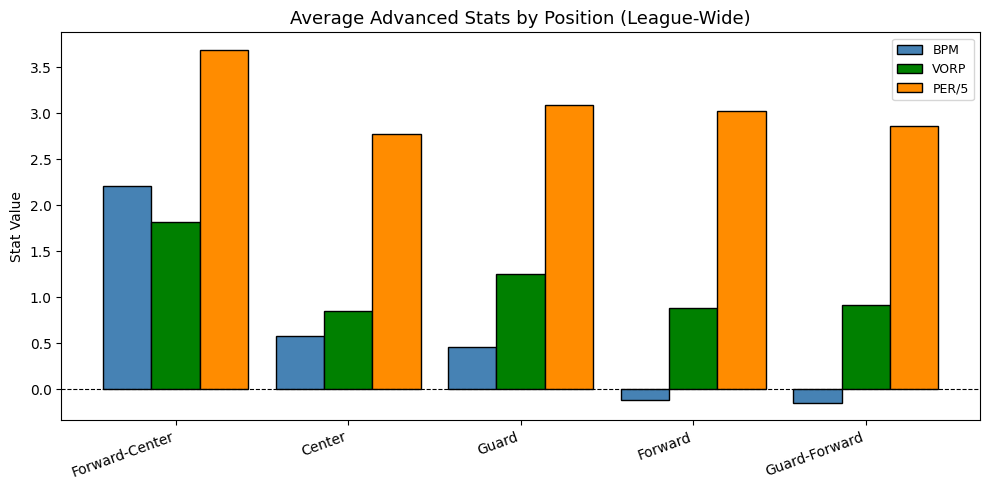

```python
# EDA GRAPH 4 — Average BPM by Position (Grouped Bar)

pos_plot = df2[df2["Position"].notna() & (df2["Position"] != "Unknown")].copy()
pos_bpm = pos_plot.groupby("Position")[["bpm","vorp","per"]].mean().sort_values("bpm", ascending=False)

fig, ax = plt.subplots(figsize=(10, 5))
x = range(len(pos_bpm))
width = 0.28

ax.bar([i - width for i in x], pos_bpm["bpm"],      width=width, label="BPM",    color="steelblue",  edgecolor="black")
ax.bar([i          for i in x], pos_bpm["vorp"],     width=width, label="VORP",   color="green",      edgecolor="black")
ax.bar([i + width  for i in x], pos_bpm["per"] / 5,  width=width, label="PER/5",  color="darkorange", edgecolor="black")

ax.set_xticks(list(x))
ax.set_xticklabels(pos_bpm.index, rotation=20, ha="right")
ax.set_ylabel("Stat Value")
ax.set_title("Average Advanced Stats by Position (League-Wide)", fontsize=13)
ax.axhline(0, color="black", linewidth=0.8, linestyle="--")
ax.legend(fontsize=9)
plt.tight_layout()
plt.show()
```

This suggests that targeting players who can contribute across multiple statistical categories may provide more value than specialists at a single position.

```python
# EDA — NBA Trade Salary Matching (125% Rule)

def trade_window(salary_m):
    low  = round(salary_m * 0.80, 2)
    high = round(salary_m * 1.25 + 0.1, 2)
    return low, high

griz2_trade = griz2[["full_name", "salary_M", "composite_score"]].copy()
griz2_trade["trade_min_M"] = griz2_trade["salary_M"].apply(lambda x: trade_window(x)[0])
griz2_trade["trade_max_M"] = griz2_trade["salary_M"].apply(lambda x: trade_window(x)[1])

print("Memphis Grizzlies — Legal Trade Salary Windows (125% CBA Rule):")
display(griz2_trade.sort_values("salary_M", ascending=False).round(2))

# For each Grizzlies player, find legal salary-matched targets
non_griz2 = df2[df2["Team"] != "MEM"].copy()
trade_results = []

for _, gp in griz2_trade.iterrows():
    lo, hi = gp["trade_min_M"], gp["trade_max_M"]
    matches = non_griz2[
        (non_griz2["salary_M"] >= lo) &
        (non_griz2["salary_M"] <= hi) &
        (non_griz2["composite_score"] > gp["composite_score"]) &  # must be an upgraded player. we don't want to trade for worse value
        (non_griz2["gamesPlayed"] >= 30)
    ].copy()
    matches["trade_away"]         = gp["full_name"]
    matches["trade_away_sal_M"]   = gp["salary_M"]
    matches["trade_away_score"]   = gp["composite_score"]
    matches["score_improvement"]  = matches["composite_score"] - gp["composite_score"]
    trade_results.append(matches)

trade_df = pd.concat(trade_results, ignore_index=True)

cols = ["trade_away", "trade_away_sal_M", "full_name", "Team",
        "Position", "age", "salary_M", "composite_score", "score_improvement"]

print(f"\nTotal legal upgrade trade options found: {len(trade_df)}")
print("\nTop upgrade trade targets by composite score improvement:")
trade_df[cols].sort_values("score_improvement", ascending=False)\
    .drop_duplicates(subset="full_name").head(20).round(2)
```

```
Memphis Grizzlies — Legal Trade Salary Windows (125% CBA Rule):
```

|  | full_name | salary_M | composite_score | trade_min_M | trade_max_M |
| --- | --- | --- | --- | --- | --- |
| 354 | Ja Morant | 36.73 | -0.03 | 29.38 | 46.01 |
| 24 | Desmond Bane | 34.01 | 1.64 | 27.20 | 42.61 |
| 236 | Jaren Jackson | 25.26 | 0.35 | 20.21 | 31.67 |
| 17 | Marvin Bagley III | 12.50 | 1.09 | 10.00 | 15.72 |
| 100 | Brandon Clarke | 12.50 | -0.74 | 10.00 | 15.72 |
| 269 | Luke Kennard | 9.25 | 0.86 | 7.40 | 11.66 |
| 281 | John Konchar | 6.16 | 0.91 | 4.93 | 7.81 |
| 150 | Zach Edey | 5.76 | 0.78 | 4.61 | 7.30 |
| 123 | Johnny Davis | 5.29 | 0.39 | 4.23 | 6.71 |
| 4 | Santi Aldama | 3.96 | 1.16 | 3.17 | 5.05 |
| 571 | Vince Williams Jr. | 2.12 | 0.00 | 1.70 | 2.75 |
| 224 | Jay Huff | 2.09 | 0.88 | 1.67 | 2.71 |
| 398 | Scotty Pippen Jr. | 2.09 | -0.34 | 1.67 | 2.71 |
| 95 | Kennedy Chandler | 2.02 | -1.03 | 1.62 | 2.62 |
| 234 | GG Jackson | 1.89 | 0.14 | 1.51 | 2.46 |
| 547 | Jaylen Wells | 1.16 | -0.55 | 0.93 | 1.55 |
| 486 | Lamar Stevens | 0.62 | -0.09 | 0.50 | 0.88 |
| 131 | Mamadi Diakite | 0.46 | 1.39 | 0.37 | 0.68 |

```
Total legal upgrade trade options found: 165

Top upgrade trade targets by composite score improvement:
```

|  | trade_away | trade_away_sal_M | full_name | Team | Position | age | salary_M | composite_score | score_improvement |
| --- | --- | --- | --- | --- | --- | --- | --- | --- | --- |
| 140 | Ja Morant | 36.73 | Shai Gilgeous-Alexander | OKC | Guard | 27.0 | 35.86 | 6.35 | 6.37 |
| 68 | Brandon Clarke | 12.50 | Victor Wembanyama | SAS | Forward-Center | 22.0 | 12.77 | 5.31 | 6.05 |
| 40 | Brandon Clarke | 12.50 | Cade Cunningham | DET | Guard | 24.0 | 13.94 | 3.61 | 4.35 |
| 37 | Brandon Clarke | 12.50 | Scottie Barnes | TOR | Guard-Forward | 24.0 | 10.13 | 2.92 | 3.67 |
| 46 | Brandon Clarke | 12.50 | Chet Holmgren | OKC | Forward-Center | 23.0 | 10.88 | 2.80 | 3.54 |
| 150 | Ja Morant | 36.73 | Tyrese Maxey | PHI | Guard | 25.0 | 35.15 | 3.48 | 3.51 |
| 35 | Brandon Clarke | 12.50 | Deni Avdija | POR | Forward | 25.0 | 15.62 | 2.74 | 3.49 |
| 152 | Ja Morant | 36.73 | Donovan Mitchell | CLE | Guard | 29.0 | 35.41 | 3.23 | 3.25 |
| 135 | Ja Morant | 36.73 | Anthony Davis | DAL | Forward-Center | 31.0 | 43.22 | 3.03 | 3.05 |
| 154 | Ja Morant | 36.73 | Jamal Murray | DEN | Guard | 28.0 | 36.02 | 2.99 | 3.02 |
| 61 | Brandon Clarke | 12.50 | Mitchell Robinson | NYK | Forward-Center | 27.0 | 14.32 | 2.18 | 2.92 |
| 52 | Brandon Clarke | 12.50 | Evan Mobley | CLE | Center | 24.0 | 11.23 | 2.16 | 2.90 |
| 43 | Brandon Clarke | 12.50 | Daniel Gafford | DAL | Forward-Center | 25.0 | 13.39 | 2.09 | 2.83 |
| 137 | Ja Morant | 36.73 | Anthony Edwards | MIN | Guard | 24.0 | 42.18 | 2.78 | 2.81 |
| 134 | Ja Morant | 36.73 | LaMelo Ball | CHO | Guard | 24.0 | 35.15 | 2.77 | 2.80 |
| 147 | Ja Morant | 36.73 | Kyrie Irving | DAL | Guard | 30.0 | 41.00 | 2.75 | 2.77 |
| 144 | Ja Morant | 36.73 | James Harden | LAC | Guard | 36.0 | 33.65 | 2.70 | 2.73 |
| 58 | Brandon Clarke | 12.50 | Austin Reaves | LAL | Guard | 27.0 | 12.98 | 1.96 | 2.70 |
| 158 | Ja Morant | 36.73 | Domantas Sabonis | SAC | Forward-Center | 25.0 | 40.50 | 2.64 | 2.66 |
| 34 | Brandon Clarke | 12.50 | Grayson Allen | PHO | Guard | 30.0 | 15.62 | 1.49 | 2.23 |

Applying the 125% salary matching rule makes the analysis more realistic, as it ensures that all suggested trades follow actual NBA financial rules, but a similar problem still occurs: the context of the salaries.

### model 1: Predicting Player Salary from Advanced Performance (Linear Regression)

**Research question:** Can we predict what a player should earn based solely on their on-court production?

- **Model type:** Linear Regression
- **Dependent variable (Y):** salary_M : the player's actual salary in millions
- **Independent variables (X):** vorp, bpm, ws_48, per, age, gamesPlayed, Position
- **Motivation from EDA:** Our salary vs. composite score plot (EDA Graph 1) shows clear spread. Many players are paid far above or below what their advanced stats predict. A regression model quantifies that gap precisely, turning a visual observation into a ranked list of every mispriced contract in the league.
- **Expected outcome:** The residual (actual minus predicted salary) ranks players by how over- or under-paid they are. Players with large positive residuals are overpaid, Memphis trade candidates. Players with large negative residuals are undervalued exactly who Memphis should target.
- **Validation method:** 80/20 train/test split on all non-Grizzlies players. Evaluate with RMSE and R². Apply to the full league to generate a mispriced contract ranking.

### Model 2: Classifying Contract Quality (Logistic Regression)

**Research question:** Can we automatically classify an NBA contract as "Good Value," "Fair," or "Overpaid" using performance and salary features?

- **Model type:** Logistic Regression (multinomial)
- **Dependent variable (Y):** contract_quality : three-class label derived from percentile cutoffs on adv_value_score, already built in our EDA
- **Independent variables (X):** salary_M, composite_score, age, gamesPlayed, Position
- **Motivation from EDA:** Our contract quality cross-tabulation shows a clear pattern between salary band and contract quality. A trained classifier can generalize this pattern to instantly screen any incoming trade candidate or free agent without computing a score manually
- **Expected outcome:** A classifier that labels any player's contract Good Value / Fair / Overpaid with probability estimates. Applied to our salary-matched trade targets, it ranks candidates by contract quality automatically and gives the Grizzlies front office a fast acquisition filter.
- **Validation method:** Train on all non-Grizzlies players, hold out a test set, evaluate with confusion matrix and classification report. Apply trained model to Grizzlies roster and trade target list.

# Conclusion